# R-code for ‘Surviving in a changing world: weather and juvenile condition matter for a long-lived avian predator, but blood parasites do not appear to’

Meinolf Ottensmann, Anja Wiegmann, Tony Rinaud, Oliver Krüger, Christina Strube, Jamie Winternitz and Nayden Chakarov

This document provides all the `R code` used in our paper. Both the Rmarkdown file and the data can be downloaded from the accompanying GitHub repository on (https://github.com/mottensmann/BuzzardSurvival) as a zip archive containing all the files. We recommend to download or clone this [GitHub repository](https://github.com/mottensmann/BuzzardSurvival) in order to access the documentation together with all the files that are needed to repeat analyses shown in this document. Just click on the link above and then on the green box `Clone or download`. In order to function properly, the same structure of folders must be kept. If you have any questions, don’t hesitate to contact meinolf.ottensmann@web.de

In order to repeat analyses presented in this manuscript program [`MARK` click here](http://www.phidot.org/software/mark/) needs to be installed. Additionally, a number of packages that extend the functionalities of base `R` are required. If not available, these packages can be installed using the code below:

```r
if ("emmeans" %in% rownames(installed.packages())) {
  library("emmeans")
  emmeans::emm_options(lmerTest.limit = 9999)
  emmeans::emm_options(pbkrtest.limit = 9999)

} else {
  install.packages("emmeans")
}
if ("EnvStats" %in% rownames(installed.packages())) {
  library("EnvStats")
} else {
  install.packages("EnvStats")
}
if ("forestmodel" %in% rownames(installed.packages())) {
  library("forestmodel")
} else {
  install.packages(forestmodel)
}
if ("lme4" %in% rownames(installed.packages())) {
  library("lme4")
} else {
  install.packages(lme4)
}
if ("magrittr" %in% rownames(installed.packages())) {
  library("magrittr")
} else {
  install.packages(magrittr)
}
if ("patchwork" %in% rownames(installed.packages())) {
  library("patchwork")
} else {
  install.packages(patchwork)
}
if ("RMark" %in% rownames(installed.packages())) {
  library("RMark")
} else {
  install.packages(RMark)
}
if ("sjPlot" %in% rownames(installed.packages())) {
  library("sjPlot")
} else {
  install.packages(sjPlot)
}
if ("sjlabelled" %in% rownames(installed.packages())) {
  library("sjlabelled")
} else {
  install.packages(sjlabelled)
}
if ("sjmisc" %in% rownames(installed.packages())) {
  library("sjmisc")
} else {
  install.packages(sjmisc)
}
if ("tidyverse" %in% rownames(installed.packages())) {
  library("tidyverse")
} else {
  install.packages(tidyverse)
}
if ("egg" %in% rownames(installed.packages())) {
  library("egg")
} else {
  install.packages(egg)
}
if ("latex2exp" %in% rownames(installed.packages())) {
  library("latex2exp")
} else {
  install.packages(latex2exp)
}
```

Furthermore, a number of custom scripts are required. All of these are available within the file `R/custom_functions.R`. The function `source()` enables to use them.

```r
source("R/custom_functions.R")
```

Individual-specific data are available as `ringing_data` (i.e., details on ringing dates and individual-specific covariates) and `resighting_data` (i.e., details on live encounters).

```r
ringing_data <- as.data.frame(read_csv("data/ringing_data.csv"))
resighting_data <- as.data.frame(read_csv("data/resighting_data.csv")) %>%
  filter(Ring %in% ringing_data$Ring)
```

Additionally, we use North Atlantic oscillation (`NAO`) indices that are based on the principal component approach [^8], retrieved from https://climatedataguide.ucar.edu/climate-data/hurrell-north-atlantic-oscillation-nao-index-pc-based (last changed 2021-08-28). As recording intervals cross years (May - April), NAO indices for the subsequent year need to be assigned: E.g., 2007 and DJFM 2008.

Note, for each recording interval, DJFM values of the subsequent year are used (e.g., cohort 2007 = NAO in 2008). This is taken care of by defining years

```r
nao <- read.table("data/nao.txt", header = T) %>%
  mutate(time = as.factor(year - 1))
```

The two periods December-March (DJFM) and December-February (DJF) are strongly correlated, hence we use only the DJFM index as a proxy of climate conditions.

```r
cor.test(nao$DJFM, nao$DJF)
```

```
#>
#>  Pearson's product-moment correlation
#>
#> data:  nao$DJFM and nao$DJF
#> t = 10.947, df = 13, p-value = 6.235e-08
#> alternative hypothesis: true correlation is not equal to 0
#> 95 percent confidence interval:
#>  0.8521755 0.9835328
#> sample estimates:
#>       cor
#> 0.9498102
```

Additionally, to simplify the interpretation of NAO-effects, we queried weather data from local weather stations using the package `rdwd`:

```r
## climate data for a radius of 60 km around the study area
## -----------------------------------------------------------------------------
climate.data <- readRDS("data/climate.data.RDS")
## assess raw data (station-specific records)
## -----------------------------------------------------------------------------
raw <- climate.data$raw
table(raw$station)
```

```
#>
#>              Alfhausen   Bielefeld-Deppendorf               Diepholz
#>                   1698                   1698                   1698
#>       Lippspringe, Bad Lippstadt-Boekenfoerde    Muenster/Osnabrueck
#>                   1698                   1698                   1698
#>     Rahden-Kleinendorf         Salzuflen, Bad
#>                   1698                   1698
```

Records of individuals are highly correlated as shown below. Hence, for downstream analyses climate data are averaged across station.

```r
## Expand data for correlation matrix
## -----------------------------------------------------------------------------
comb <- data.frame(station = rep(unique(raw$station), 3),
                       var = rep(c("temp", "snow", "precip"), each = 8))

## write data to a matrix to compute correlation coefficients
## -----------------------------------------------------------------------------
mat <- matrix(NA, nrow = 1698, ncol = nrow(comb))
for (i in 1:nrow(comb)) {
  mat[,i] <- raw[[comb$var[i]]][raw$station == comb$station[i]]
}
## Temperature: Average air temperature
## -----------------------------------------------------------------------------
(r <- cor(mat[,1:8], use = "complete"))
```

```
#>           [,1]      [,2]      [,3]      [,4]      [,5]      [,6]      [,7]
#> [1,] 1.0000000 0.9850755 0.9859444 0.9771406 0.9832438 0.9876263 0.9789108
#> [2,] 0.9850755 1.0000000 0.9803284 0.9878351 0.9765467 0.9850025 0.9742077
#> [3,] 0.9859444 0.9803284 1.0000000 0.9637159 0.9617787 0.9814514 0.9954603
#> [4,] 0.9771406 0.9878351 0.9637159 1.0000000 0.9861124 0.9804636 0.9547703
#> [5,] 0.9832438 0.9765467 0.9617787 0.9861124 1.0000000 0.9815192 0.9515472
#> [6,] 0.9876263 0.9850025 0.9814514 0.9804636 0.9815192 1.0000000 0.9781038
#> [7,] 0.9789108 0.9742077 0.9954603 0.9547703 0.9515472 0.9781038 1.0000000
#> [8,] 0.9853653 0.9790248 0.9940019 0.9624915 0.9630116 0.9858063 0.9939833
#>           [,8]
#> [1,] 0.9853653
#> [2,] 0.9790248
#> [3,] 0.9940019
#> [4,] 0.9624915
#> [5,] 0.9630116
#> [6,] 0.9858063
#> [7,] 0.9939833
#> [8,] 1.0000000
```

```r
round(range(r[r < 1]),2)
```

```
#> [1] 0.95 1.00
## Snow: Days with snow cover
## -----------------------------------------------------------------------------
```

```r
(r <- cor(mat[,9:16], use = "complete"))
```

```
#>           [,1]      [,2]      [,3]      [,4]      [,5]      [,6]      [,7]
#> [1,] 1.0000000 0.7659532 0.7572649 0.7864370 0.7411595 0.7745165 0.7166570
#> [2,] 0.7659532 1.0000000 0.7010127 0.7714660 0.7156688 0.7038765 0.6620567
#> [3,] 0.7572649 0.7010127 1.0000000 0.7212875 0.6938560 0.7152633 0.8647198
#> [4,] 0.7864370 0.7714660 0.7212875 1.0000000 0.7411595 0.6973705 0.6909417
#> [5,] 0.7411595 0.7156688 0.6938560 0.7411595 1.0000000 0.7536188 0.6550266
#> [6,] 0.7745165 0.7038765 0.7152633 0.6973705 0.7536188 1.0000000 0.7143564
#> [7,] 0.7166570 0.6620567 0.8647198 0.6909417 0.6550266 0.7143564 1.0000000
#> [8,] 0.7586577 0.7164559 0.8242534 0.7004202 0.6762527 0.7661831 0.8166727
#>           [,8]
#> [1,] 0.7586577
#> [2,] 0.7164559
#> [3,] 0.8242534
#> [4,] 0.7004202
#> [5,] 0.6762527
#> [6,] 0.7661831
#> [7,] 0.8166727
#> [8,] 1.0000000
```

```r
round(range(r[r < 1]),2)
```

```
#> [1] 0.66 0.86
## Precipitation levels
## -----------------------------------------------------------------------------
```

```r
(r <- cor(mat[,17:24], use = "complete"))
```

```
#>           [,1]      [,2]      [,3]      [,4]      [,5]      [,6]      [,7]
#> [1,] 1.0000000 0.9007638 0.8428631 0.8308433 0.7618405 0.8570406 0.8296731
#> [2,] 0.9007638 1.0000000 0.8468045 0.8647865 0.7869062 0.8385375 0.8190802
#> [3,] 0.8428631 0.8468045 1.0000000 0.7549503 0.7138465 0.8400509 0.9161689
#> [4,] 0.8308433 0.8647865 0.7549503 1.0000000 0.8497984 0.7652775 0.7252611
#> [5,] 0.7618405 0.7869062 0.7138465 0.8497984 1.0000000 0.7384674 0.6736237
#> [6,] 0.8570406 0.8385375 0.8400509 0.7652775 0.7384674 1.0000000 0.8238245
#> [7,] 0.8296731 0.8190802 0.9161689 0.7252611 0.6736237 0.8238245 1.0000000
#> [8,] 0.8629663 0.8151406 0.8893772 0.7412659 0.6872741 0.8454145 0.9271625
#>           [,8]
#> [1,] 0.8629663
#> [2,] 0.8151406
#> [3,] 0.8893772
#> [4,] 0.7412659
#> [5,] 0.6872741
#> [6,] 0.8454145
#> [7,] 0.9271625
#> [8,] 1.0000000
```

```r
round(range(r[r < 1]),2)
```

```
#> [1] 0.67 0.93
## Correlation with NAO
## -----------------------------------------------------------------------------
```

```r
climate.data$season$time <- as.factor(climate.data$season$time)
nao <- left_join(nao, climate.data$season, by = "time")
with(filter(nao, year > 2007), cor(DJFM, snow))
```

```
#> [1] -0.8977389
```

```r
with(filter(nao, year > 2007), cor(DJFM, temp))
```

```
#> [1] 0.8165673
```

```r
with(filter(nao, year > 2007), cor(DJFM, precip))
```

```
#> [1] 0.298905
```

This analysis is based on data from a long-term study on common buzzards *Buteo buteo* comprising individuals that were ringed as nestling and individually marked with wing-tags in the period 2007 to 2020 Note, due to logistic constraints there is no information on *Leucocytozoon* infections available for the cohort of 2008 and thus individuals from that cohort are omitted from analyses.

## Modelling of survival probabilities

### Capture-Mark-Resighting analysis

We model survival probabilities using combined dead and live encounter events using the `Barker` model implemented in software `MARK`. This model does not allow missing covariates and hence we need to subset the dataset first (i.e., removing the cohort of 2008 where no data on *Leucocytozoon* infection status is available):

```r
## Subset to wing-tagged birds with complete covariates
## ----------------------------------------------------
ringing_data <- filter(
  ringing_data,
  # Subset to wing-tagged only
  Tag ==  1,
  # Remove birds that died in the nest
  !CauseDeath %in% "Dead as chick",
  # Remove two birds predated as nestling
  !Ring %in% c("3408543", "3417787"),
  # known Sex
  !is.na(Sex),
  # No missing covariate
  !is.na(Lprev),
  # Keep birds with assigned morph
  Morph %in% 2:4) %>%
  #mutate(Rank = case_when(Rank == "1" ~ "A", Rank != "1" ~ "B")) %>%
  mutate(Lbinom = as.factor(ifelse(Lprev == 0, "Uninfected", "Infected"))) %>%
  ## scale continuous variables
  mutate(Hatch = scale(Hatch)) %>%
  mutate(Age_days = scale(Age_days)) %>%
  mutate(BCI = scale(BCI))
```

At this stage, we retain a total of 2723 individuals, corresponding to a mean cohort size of 209.4615385 [Range: 51 - 431].

Based on ringing data and re-sightings of individuals, we assemble combined live-dead encounter histories for all individuals using the custom function `create.ld.barker`. This functions generates a vector of the form `LDLDLD`, where `L` codes captures (here, only the marking occasion) and `D` codes both dead recoveries (D = 1) and live re-sightings (D = 2) between sampling intervals. Together, each `LD` pair codes for one interval of the study period. Next, we define the model structure for the `Barker` model and code the required design data.

```r
## NOT run, output is saved
## Code capture histories (ch) and reformat data
## ------------------------------------------------------
df.barker <- data.frame(
  ringing_data,
  ch =  create.ld.barker(
    start = 2007,
    end = 2020,
    ringing_data = ringing_data,
    resights = resighting_data)) %>%
  mutate(ch = as.character(ch)) %>%
  mutate(Morph = factor(Morph, labels = c("D","I","L"))) %>%
  mutate(Sex = as.factor(Sex)) %>%
  subset(., select = -c(Ring, Tag, Dead, DateDeath, CauseDeath))

## process the data for RMark
## ------------------------------------------------------
dp.barker  <- process.data(data = df.barker, model = "Barker", begin.time = 2007,
                        groups = c("Sex", "Morph", "Lbinom"))

## create design data
## ------------------------------------------------------
ddl.barker <- make.design.data(dp.barker)

## Bin age-classes
## Survival S:
## ------------------------------------------------------
ddl.barker <- add.design.data(
  data = dp.barker, ddl = ddl.barker, parameter="S", type = "age",
  name = "age", bins = c(0, 1, 2, 13),
  right = FALSE, replace = TRUE)

ddl.barker$S$y1 <- 0
ddl.barker$S$y1[ddl.barker$S$age == "[0,1)"] <- 1
covars <- left_join(data.frame(time = ddl.barker$S$time), nao, "time")
ddl.barker$S$NAO <- covars$DJFM

## Further parameters
## -----------------------------------------------------------------------------
ddl.barker <- add.design.data(
  data = dp.barker, ddl = ddl.barker, parameter="R", type = "age",
  name = "age", bins = c(0, 1, 2, 13),
  right = FALSE, replace = TRUE)

ddl.barker <- add.design.data(
  data = dp.barker, ddl = ddl.barker, parameter="r", type = "age",
  name = "age", bins = c(0, 1, 2, 13),
  right = FALSE, replace = TRUE)

ddl.barker <- add.design.data(
  data = dp.barker, ddl = ddl.barker, parameter="RPrime", type = "age",
  name = "age", bins = c(0, 1, 2, 13),
  right = FALSE, replace = TRUE)

ddl.barker$r <- ddl.barker$r %>%
  mutate(ageclass2 = case_when(
    age == "[0,1)" ~ "Juvenile",
    age != "[0,1)" ~ "Adult"
  ))

ddl.barker$R <- ddl.barker$R %>%
  mutate(ageclass2 = case_when(
    age == "[0,1)" ~ "Juvenile",
    age != "[0,1)" ~ "Adult"
  ))

ddl.barker$RPrime <- ddl.barker$RPrime %>%
  mutate(ageclass2 = case_when(
    age == "[0,1)" ~ "Juvenile",
    age != "[0,1)" ~ "Adult"
  ))

## Save files for later use
## -----------------------------------------------------------------------------
saveRDS(df.barker, file = "data/df.barker.RDS", compress = "bzip2")
saveRDS(dp.barker, file = "data/dp.barker.RDS", compress = "bzip2")
saveRDS(ddl.barker, file = "data/ddl.barker.RDS", compress = "bzip2")
```

Load data previously aggregated using the above code

```r
df.barker <- readRDS("data/df.barker.RDS")
dp.barker <- readRDS("data/dp.barker.RDS")
ddl.barker <- readRDS("data/ddl.barker.RDS")
```

#### Estimating c-hat based on bootstrapping

The following code allows to estimate $\hat{C}$ based on parametric bootstrapping. For this purpose, first a general model structure is fitted to obtain model estimates. These estimates are then used to simulate capture histories that are re-analysed using the same model. *Because of considerable computation time, the output is saved within the repository and loaded later on. Also, as indicated above it is required to have program MARK installed on the computer when repeating the calculations*.

```r
## Run global model to estimate parameters based on the raw data
## -----------------------------------------------------------------------------
global.model <- mark(
  dp.barker,  ddl.barker, silent = FALSE, output = FALSE, invisible = TRUE,
  model.parameters = list(
    S = list(formula = ~ age + time + Sex,
             fixed = list(time = 2008, value = 1)),
    p = list(formula = ~ 1, fixed = 0),
    F = list(formula = ~ 1, fixed = 1),
    FPrime = list(formula = ~ 1, fixed = 0),
    R = list(formula = ~ time + Sex, fixed = list(time = 2008, value = 0)),
    RPrime = list(formula = ~ ageclass2 + Sex),
    r = list(formula = ~ ageclass2 + Sex, fixed = list(cohort = 2008, value = 0))),
  model = 'Barker')
## clean up unused files
## -----------------------------------------------------------------------------
cleanup(ask = FALSE)

## Extract estimated parameters
## --------------------------------------------------------
params <- lapply(row.names(global.model$results$real), function(x) {
  stringr::str_split(x, pattern = " ")[[1]]
}) %>%
  do.call("rbind",.) %>%
  as.data.frame() %>%
  set_colnames(c("Parameter", "Group", "Cohort", "age", "time")) %>%
  mutate(time = substr(time, 2, nchar(time)) %>% as.numeric()) %>%
  mutate(age = substr(age, 2, nchar(age)) %>% as.numeric()) %>%
  cbind(., global.model$results$real)


## Split by parameter (S, r, p & F) and group (Female, Male)
## --------------------------------------------------------

## Survival:
## --------------------------------------------------------
S.f <- filter(params, Group == "gFemaleDInfected", Parameter == "S")
S.m <- filter(params, Group == "gMaleDInfected", Parameter == "S")

## Recovery probability
## --------------------------------------------------------
r.f <- filter(params, Group == "gFemaleDInfected", Parameter == "r")
r.m <- filter(params, Group == "gMaleDInfected", Parameter == "r")

## Re-sighting probability. --> time 2008 set to zero
## --------------------------------------------------------
R.f <- filter(params, Group == "gFemaleDInfected",  Parameter == "R")
R.f.2008 <- R.f[1,]; R.f.2008$time <- 2008; R.f.2008$age <- 1; R.f.2008$estimate <- 0
R.f <-rbind(R.f, R.f.2008)
RPrime.f <- filter(params, Group == "gFemaleDInfected", Parameter == "R'")

R.m <- filter(params, Group == "gMaleDInfected",  Parameter == "R")
R.m.2008 <- R.m[1,]; R.m.2008$time <- 2008; R.m.2008$age <- 1; R.m.2008$estimate <- 0
R.m <-rbind(R.m, R.m.2008)

RPrime.m <- filter(params, Group == "gMaleDInfected", Parameter == "R'")

## get group table to assign parameters correctly in the bs model
## --------------------------------------------------------
(group.table <- filter(dp.barker$data[,c("group", "Sex", "Morph", "Lbinom")]) %>%
  unique.data.frame() %>%
  .[with(., order(Sex, Morph, Lbinom)),])


## conduct simulations using parametric bs for both models
## -----------------------------------------------------------------------------
sim.out <- sims.barker(
  S.fem = S.f, S.mal = S.m, R.fem = R.f, R.mal = R.m,
  RPrime.fem = RPrime.f, RPrime.mal = RPrime.m, r.mal = r.m, r.fem = r.f,
  marked =  Marked(
    data = dp.barker$data, n.occasions = nchar(dp.barker$data$ch[1])/2,
    groups = group.table$group, group.col = "group"),
  reps = 999,
  model.parameters = list(
    S = list(formula = ~ age + time + Sex,
             fixed = list(cohort = 2008, value = 1)),
    p = list(formula = ~ 1, fixed = 0),
    F = list(formula = ~ 1, fixed = 1),
    FPrime = list(formula = ~ 1, fixed = 0),
    R = list(formula = ~ time + Sex, fixed = list(time = 2008, value = 0)),
    RPrime = list(formula = ~ ageclass2 + Sex),
    r = list(formula = ~ ageclass2 + Sex, fixed = list(cohort = 2008, value = 0))))

## Save output for later use
## -----------------------------------------------------------------------------
  save(sim.out, file = "data/sim.out.barker.RData")
  c.hat <- list(median = global.model$results$deviance/sim.out$deviance.median,
                lcl = global.model$results$deviance/sim.out$deviance.025,
                ucl = global.model$results$deviance/sim.out$deviance.975)
  save(c.hat, file = "data/c.hat.barker.RData")
  cleanup(ask = FALSE)
```

Inspect results of the bootstrapping exercise:

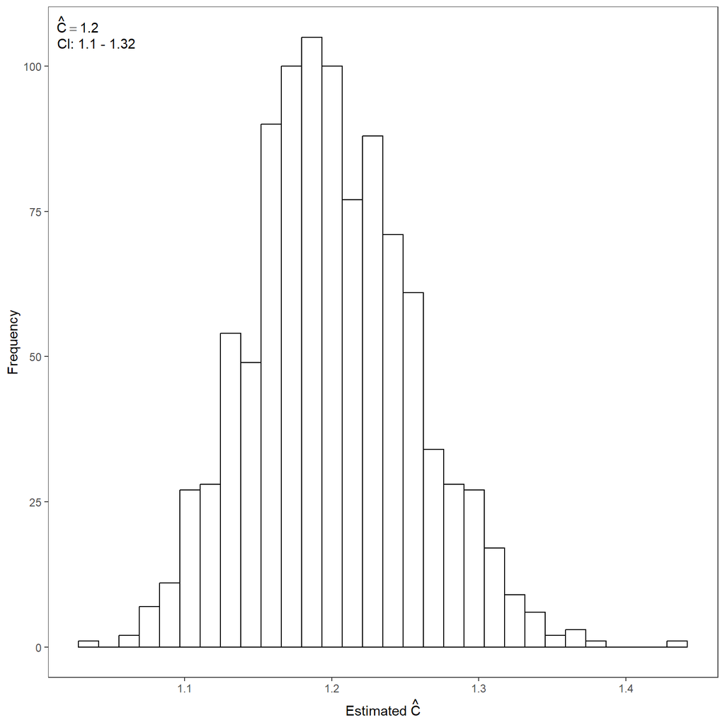

```r
## Load data generated using the code chunk above
## -----------------------------------------------------------------------------
load("data/sim.out.barker.RData")
load("data/c.hat.barker.RData")

## Create Figure S1, showing distribution and median estimate of c-hat
## -----------------------------------------------------------------------------
Fig_S1 <- ggplot(data.frame(x = (c.hat$median*sim.out$deviance.median)/sim.out$deviance.raw), aes(x)) +
  geom_histogram(bins = 30, col = "black", fill = "white") +
  theme_article() +
  xlab(TeX("Estimated $\\hat{C}")) +
  ylab("Frequency") +
  annotate("text", x = -Inf, y = Inf, hjust = -0.2, vjust = 1.5,
           label = TeX(paste0("$\\hat{C} = ", round(c.hat$median,2)),
                       output = 'character'),parse = T) +
  annotate("text", x = -Inf, y = Inf, hjust = -0.12, vjust = 4,
           label = paste("CI:", round(c.hat$ucl,2), "-", round(c.hat$lcl,2)))
Fig_S1
```

```r
## Save file to disk
## -----------------------------------------------------------------------------
ggsave(plot = Fig_S1, filename =  "plots/Fig_S1.pdf",
        device = "pdf", dpi = 1200, width = 6, height = 4, units = "in")
ggsave(plot = Fig_S1, filename = "plots/Fig_S1.png",
        device = "png", dpi = 1200, width = 6, height = 4, units = "in")
```

#### Candidate models

Build all combinations of model formulas and fit candidate models. To adjust for overdispersion, the estimated $\hat{C}$ is used. *Running all models takes time and hence we also provide the output files*.

```r
do_analysis.barker = function(dp.barker, ddl.barker) {
  ## Models for Survival S
  ## ---------------------------------------------------------------------------

  ## Null model: Only age-specific survival rates
  ## ---------------------------------------------------------------------------
  S.01 = list(formula = ~ age, fixed = list(cohort = 2008, value = 1))

  ## Simple time and climate-dependent models
  ## ---------------------------------------------------------------------------
  S.02 = list(formula = ~ age + time, fixed = list(cohort = 2008, value = 1))
  S.03 = list(formula = ~ age + NAO, fixed = list(cohort = 2008, value = 1))
  S.04 = list(formula = ~ age * NAO, fixed = list(cohort = 2008, value = 1))
  S.05 = list(formula = ~ age + NAO + time, fixed = list(cohort = 2008, value = 1))
  S.06 = list(formula = ~ age * NAO + time, fixed = list(cohort = 2008, value = 1))

  ## Adding sex-specific rates
  ## ---------------------------------------------------------------------------
  S.07 = list(formula = ~ age + Sex, fixed = list(cohort = 2008, value = 1))
  S.08 = list(formula = ~ age + time + Sex, fixed = list(cohort = 2008, value = 1))
  S.09 = list(formula = ~ age + NAO + Sex, fixed = list(cohort = 2008, value = 1))
  S.10 = list(formula = ~ age * NAO + Sex, fixed = list(cohort = 2008, value = 1))
  S.11 = list(formula = ~ age + NAO + time + Sex, fixed = list(cohort = 2008, value = 1))
  S.12 = list(formula = ~ age * NAO + time + Sex, fixed = list(cohort = 2008, value = 1))

  ## Adding Morphs
  ## ---------------------------------------------------------------------------
  S.13 = list(formula = ~ age + Morph, fixed = list(cohort = 2008, value = 1))
  S.14 = list(formula = ~ age + time + Morph, fixed = list(cohort = 2008, value = 1))
  S.15 = list(formula = ~ age + NAO + Morph, fixed = list(cohort = 2008, value = 1))
  S.16 = list(formula = ~ age * NAO + Morph, fixed = list(cohort = 2008, value = 1))
  S.17 = list(formula = ~ age + NAO + time + Morph, fixed = list(cohort = 2008, value = 1))
  S.18 = list(formula = ~ age * NAO + time + Morph, fixed = list(cohort = 2008, value = 1))

  ## Adding Leucocytozoon prevalence, main effect and interaction terms
  ## ---------------------------------------------------------------------------
  S.19 = list(formula = ~ age + Lbinom, fixed = list(cohort = 2008, value = 1))
  S.20 = list(formula = ~ age + time + Lbinom, fixed = list(cohort = 2008, value = 1))
  S.21 = list(formula = ~ age + NAO + Lbinom, fixed = list(cohort = 2008, value = 1))
  S.22 = list(formula = ~ age * NAO + Lbinom, fixed = list(cohort = 2008, value = 1))
  S.23 = list(formula = ~ age + NAO + time + Lbinom, fixed = list(cohort = 2008, value = 1))
  S.24 = list(formula = ~ age * NAO + time + Lbinom, fixed = list(cohort = 2008, value = 1))
  S.25 = list(formula = ~ age + y1:Lbinom, fixed = list(cohort = 2008, value = 1))
  S.26 = list(formula = ~ age + time + y1:Lbinom, fixed = list(cohort = 2008, value = 1))
  S.27 = list(formula = ~ age + NAO + y1:Lbinom, fixed = list(cohort = 2008, value = 1))
  S.28 = list(formula = ~ age * NAO + y1:Lbinom, fixed = list(cohort = 2008, value = 1))
  S.29 = list(formula = ~ age + NAO + time + y1:Lbinom, fixed = list(cohort = 2008, value = 1))
  S.30 = list(formula = ~ age * NAO + time + y1:Lbinom, fixed = list(cohort = 2008, value = 1))
  #S.31 = list(formula = ~ age + y1:Age_days:Lbinom, fixed = list(cohort = 2008, value = 1))
  #S.32 = list(formula = ~ age + time + y1:Age_days:Lbinom, fixed = list(cohort = 2008, value = 1))
  #S.33 = list(formula = ~ age + NAO + y1:Age_days:Lbinom, fixed = list(cohort = 2008, value = 1))
  #S.34 = list(formula = ~ age * NAO + y1:Age_days:Lbinom, fixed = list(cohort = 2008, value = 1))
  #S.35 = list(formula = ~ age + NAO + time + y1:Age_days:Lbinom, fixed = list(cohort = 2008, value = 1))
  #S.36 = list(formula = ~ age * NAO + time + y1:Age_days:Lbinom, fixed = list(cohort = 2008, value = 1))

  ## Adding Body condition, main effect and interaction terms
  ## ---------------------------------------------------------------------------
  S.37 = list(formula = ~ age + BCI, fixed = list(cohort = 2008, value = 1))
  S.38 = list(formula = ~ age * BCI, fixed = list(cohort = 2008, value = 1))
  S.39 = list(formula = ~ age + time + BCI, fixed = list(cohort = 2008, value = 1))
  S.40 = list(formula = ~ age * BCI + time, fixed = list(cohort = 2008, value = 1))
  S.41 = list(formula = ~ age + NAO + BCI, fixed = list(cohort = 2008, value = 1))
  S.42 = list(formula = ~ age * BCI + NAO, fixed = list(cohort = 2008, value = 1))
  S.43 = list(formula = ~ age + NAO + time + BCI, fixed = list(cohort = 2008, value = 1))
  S.44 = list(formula = ~ age * BCI + time + NAO, fixed = list(cohort = 2008, value = 1))
  S.45 = list(formula = ~ age + y1:BCI, fixed = list(cohort = 2008, value = 1))
  S.46 = list(formula = ~ age + time + y1:BCI, fixed = list(cohort = 2008, value = 1))
  S.47 = list(formula = ~ age + NAO + y1:BCI, fixed = list(cohort = 2008, value = 1))
  S.48 = list(formula = ~ age + NAO + time + y1:BCI, fixed = list(cohort = 2008, value = 1))
  S.49 = list(formula = ~ age * NAO + y1:BCI, fixed = list(cohort = 2008, value = 1))
  S.50 = list(formula = ~ age * NAO + time + y1:BCI, fixed = list(cohort = 2008, value = 1))

  ## Adding brood rank
  ## ---------------------------------------------------------------------------
  S.51 = list(formula = ~ age + y1:Rank, fixed = list(cohort = 2008, value = 1))
  S.52 = list(formula = ~ age + time + y1:Rank, fixed = list(cohort = 2008, value = 1))
  S.53 = list(formula = ~ age + NAO + y1:Rank, fixed = list(cohort = 2008, value = 1))
  S.54 = list(formula = ~ age * NAO + y1:Rank, fixed = list(cohort = 2008, value = 1))
  S.55 = list(formula = ~ age + NAO + time + y1:Rank, fixed = list(cohort = 2008, value = 1))
  S.56 = list(formula = ~ age * NAO + time + y1:Rank, fixed = list(cohort = 2008, value = 1))

  ## Adding Hatching date to account for seasonal effects on juvenile survival
  ## ---------------------------------------------------------------------------
  S.57 = list(formula = ~ age + y1:Hatch, fixed = list(cohort = 2008, value = 1))
  S.58 = list(formula = ~ age + time + y1:Hatch, fixed = list(cohort = 2008, value = 1))
  S.59 = list(formula = ~ age + NAO + y1:Hatch, fixed = list(cohort = 2008, value = 1))
  S.60 = list(formula = ~ age * NAO + y1:Hatch, fixed = list(cohort = 2008, value = 1))
  S.61 = list(formula = ~ age + NAO + time + y1:Hatch, fixed = list(cohort = 2008, value = 1))
  S.62 = list(formula = ~ age * NAO + time + y1:Hatch, fixed = list(cohort = 2008, value = 1))

  ## Adding age at sampling date, restricted to juvenile survival rates
  ## ---------------------------------------------------------------------------
  S.63 = list(formula = ~ age + y1:Age_days, fixed = list(cohort = 2008, value = 1))
  S.64 = list(formula = ~ age + time + y1:Age_days, fixed = list(cohort = 2008, value = 1))
  S.65 = list(formula = ~ age + NAO + y1:Age_days, fixed = list(cohort = 2008, value = 1))
  S.66 = list(formula = ~ age * NAO + y1:Age_days, fixed = list(cohort = 2008, value = 1))
  S.67 = list(formula = ~ age + NAO + time + y1:Age_days, fixed = list(cohort = 2008, value = 1))
  S.68 = list(formula = ~ age * NAO + time + y1:Age_days, fixed = list(cohort = 2008, value = 1))

  ## Models for re-sighting probability p
  ## p.time.age: Not supported
  ## ---------------------------------------------------------------------------
  p.dot = list(formula = ~ 1, fixed = 0)

  ## Models for Site fidelity F
  ## ---------------------------------------------------------------------------
  F.fixed = list(formula = ~ 1, fixed = 1)
  FPrime.fixed = list(formula = ~ 1, fixed = 0)

  ## Models for dead recovery chances r
  ## ---------------------------------------------------------------------------
  r.dot = list(formula = ~ 1, fixed = list(cohort = 2008, value = 0))
  r.age2 = list(formula = ~ ageclass2, fixed = list(cohort = 2008, value = 0))

  R.dot =  list(formula = ~ 1)
  R.time =  list(formula = ~ time, fixed = list(time = 2008, value = 0))

  RPrime.time =  list(formula = ~ time, fixed = list(time = 2008, value = 0))
  RPrime.dot =  list(formula = ~ 1)

  ## Compile model list based on parameter combinations
  ## ---------------------------------------------------------------------------
  cml = create.model.list(model = "Barker")

  ## Run models
  ## ---------------------------------------------------------------------------
  results.barker = mark.wrapper.parallel(
    model.list = cml, data = dp.barker, ddl = ddl.barker,
    output = FALSE, silent = FALSE, cpus = 2, parallel = TRUE)
  return(results.barker)
}

## Conduct analysis using function specified above
## ---------------------------------------------------------------------------
models.barker <- do_analysis.barker(dp.barker =  dp.barker, ddl.barker = ddl.barker)

## adjust for over dispersion using c-hat and save output as a file
## ---------------------------------------------------------------------------
load("data/c.hat.barker.RData")
models.barker.adj <-  adjust.chat(model.list = models.barker, chat = c.hat$median)

## For upload on GitHub (file size limit exceeded) split in two
## output data files:
## -----------------------------------------------------------------------------
models.barker.adj_1 <- RMark::remove.mark(models.barker.adj, model.numbers = 249:496)
models.barker.adj_2 <- RMark::remove.mark(models.barker.adj, model.numbers = 1:248)
saveRDS(models.barker.adj_1, file = "data/models.barker.adj_1.RDS", compress = 'bzip2')
saveRDS(models.barker.adj_2, file = "data/models.barker.adj_2.RDS", compress = 'bzip2')

## Identify supported models based on Delta QAICc <= 7
## ---------------------------------------------------------------------------
Large.AICc <-
  rownames(models.barker.adj$model.table)[which(models.barker.adj$model.table[["DeltaQAICc"]] > 7)] %>%
  as.numeric()

## Select supported models and write output to file
## -----------------------------------------------------------------------------
supported.models.barker <- remove.mark(
  marklist = models.barker.adj,
  model.numbers = Large.AICc)
saveRDS(supported.models.barker, file = "data/supported.models.barker.RDS")

## Clean-up debris (=unused temporary files)
## -----------------------------------------------------------------------------
cleanup(ask = FALSE)
unlink(list.files(pattern = "mark", ignore.case = F))
```

#### Results

Load output summarising candidate models

```r
## Load models with adjusted deviance: Two files to merge
## -----------------------------------------------------------------------------
models.barker.adj_1 <- readRDS("data/models.barker.adj_1.RDS")
models.barker.adj_2 <- readRDS("data/models.barker.adj_2.RDS")
## Merge mark lists
## -----------------------------------------------------------------------------
models.barker.adj <- RMark::merge.mark(models.barker.adj_1, models.barker.adj_2)
rm(list = c("models.barker.adj_1", "models.barker.adj_2"))

## Load Supported models
## -----------------------------------------------------------------------------
supported.models.barker <- readRDS("data/supported.models.barker.RDS")
```

##### Model averaging

A few models are not fully estimatable due to boundary estimates. These models represent the most complicated model structure including age, time, NAO and an additional covariate (BCI or *Leucocytozoon* prevalence). These models are not considered in computing model averages of parameter S.

- S(~age + NAO + time + y1:BCI)p(<sub>1)r(</sub>ageclass2)R(<sub>time)R’(</sub>1)F(<sub>1)F’(</sub>1)
- S(~age * BCI + time + NAO)p(<sub>1)r(</sub>1)R(<sub>time)R’(</sub>1)F(<sub>1)F’(</sub>1)

```r
## Compute model averaged estimates
## -----------------------------------------------------------------------------
S.mod.avg <- model.average(supported.models.barker,
                           parameter = "S", drop = T, vcv = T)[["estimates"]] %>%
  ## estimates 2-13 are identical, but age == 3 needed for 2010!
  filter(fixed != "Fixed", age %in% 0:3) %>%
  subset(., select = c(estimate, se, lcl, ucl, age, Sex, Morph, Lbinom)) %>%
  unique.data.frame()

## Model average recovery estimates (r)
## -----------------------------------------------------------------------------
r.mod.avg <- model.average(supported.models.barker,
                           parameter = "r", drop = T, vcv = T)[["estimates"]] %>%
  filter(fixed != "Fixed") %>%
  subset(., select = (c(estimate, se, lcl, ucl, age, Sex))) %>%
  unique.data.frame()

## Model average R estimate
## -----------------------------------------------------------------------------
R.mod.avg <- model.average(supported.models.barker,
                           parameter = "R", drop = T, vcv = T)[["estimates"]] %>%
  filter(fixed != "Fixed") %>%
  subset(., select = (c(estimate, se, lcl, ucl, age, Sex))) %>%
  unique.data.frame()

## Model average R' estimate
## -----------------------------------------------------------------------------
RPrime.mod.avg <- model.average(supported.models.barker,
                           parameter = "RPrime", drop = T, vcv = T)[["estimates"]] %>%
  filter(fixed != "Fixed") %>%
  subset(., select = (c(estimate, se, lcl, ucl, age, Sex))) %>%
  unique.data.frame()
```

##### Model selection

Create a model selection table (Table S1)

```r
## Format model table
## -----------------------------------------------------------------------------
model.table <-
  models.barker.adj$model.table[,c("model", "DeltaQAICc", "weight", "npar", "QDeviance")]

## Change parameter names to enhance readability
## -----------------------------------------------------------------------------
model.table$model <-
  stringr::str_replace_all(model.table$model, "~", "")
model.table$model <-
  stringr::str_replace(model.table$model, "Lbinom", "Leucocytozoon")
model.table$model <-
  stringr::str_replace(model.table$model, "Hatch", "Hatch date")
model.table$model <-
  stringr::str_replace(model.table$model, "Age_days", "Nestling")
model.table$model <-
  stringr::str_replace(model.table$model, "BCI", "Body condition")
model.table$model <-
  stringr::str_replace(model.table$model, "ageclass2", "Ageclass2")
model.table$model <-
  stringr::str_replace(model.table$model, "age", "AgeClass3")
model.table$model <-
  stringr::str_replace(model.table$model, "Nestling", "Nestling age")
model.table$model <-
  stringr::str_replace(model.table$model, "y1", "Juvenile")
model.table$model <-
  stringr::str_replace(model.table$model, "time", "Time")
model.table$model <-
  stringr::str_replace(model.table$model, "p(1)", "p(0)")
model.table$model <-
  stringr::str_replace(model.table$model, "F(1)", "F(1)")
model.table$model <-
  stringr::str_replace(model.table$model, "F'(1)", "F'(0)")
model.table$model <-
  stringr::str_replace(model.table$model, "R'(1)", "R'(.)")
model.table$model <-
  stringr::str_replace(model.table$model, "r(1)", "r(.)")

readr::write_csv(model.table, "data/adjusted.models.barker.csv")
```

##### Parameter weights

Compute cumulative weights based on all models including a certain parameter.

```r
## Variable importance parameter S
## -----------------------------------------------------------------------------
vars <- c("time", "BCI", "NAO", "Sex", "Rank", "Hatch", "Lbinom", "y1:Age_days", "Morph", "y1:BCI")

S.weights <- sapply(vars, function(var) {
  t <- filter(models.barker.adj$model.table, stringr::str_detect(S, var))
  sum(t$weight) %>% round(.,3)
})
data.frame(Parameter = vars, weight = S.weights)
```

```
#>               Parameter weight
#> time               time  1.000
#> BCI                 BCI  0.889
#> NAO                 NAO  0.282
#> Sex                 Sex  0.011
#> Rank               Rank  0.011
#> Hatch             Hatch  0.023
#> Lbinom           Lbinom  0.016
#> y1:Age_days y1:Age_days  0.012
#> Morph             Morph  0.011
#> y1:BCI           y1:BCI  0.445
## variable importance parameter r
## -----------------------------------------------------------------------------
```

```r
vars <- c("1", "ageclass2")

r.weights <- sapply(vars, function(var) {
  t <- filter(models.barker.adj$model.table, stringr::str_detect(r, var))
  sum(t$weight) %>% round(.,3)
})
data.frame(Parameter = vars, weight = r.weights)
```

```
#>           Parameter weight
#> 1                 1  0.731
#> ageclass2 ageclass2  0.269
## variable importance parameter R
## -----------------------------------------------------------------------------
```

```r
vars <- c("1", "time")

R.weights <- sapply(vars, function(var) {
  t <- filter(models.barker.adj$model.table, stringr::str_detect(R, var))
  sum(t$weight) %>% round(.,3)
})
data.frame(Parameter = vars, weight = R.weights)
```

```
#>      Parameter weight
#> 1            1      0
#> time      time      1
## variable importance parameter R'
## -----------------------------------------------------------------------------
```

```r
vars <- c("1", "time")

RPrime.weights <- sapply(vars, function(var) {
  t <- filter(models.barker.adj$model.table, stringr::str_detect(RPrime, var))
  sum(t$weight) %>% round(.,3)
})
data.frame(Parameter = vars, weight = RPrime.weights)
```

```
#>      Parameter weight
#> 1            1      1
#> time      time      0
```

##### Survival rates (S)

Explore survival rates in relation to fixed effects.

##### Age

Visualise age and time-specific survival estimates. **Note: Except for age and time no other factor plays a role for the survival estimates (e.g., Morph, Rank, infection status)** Hence, rounding estimates at a precision of six digits allows to simplify the output in such a way that there is a single unique estimate per year and age combination.

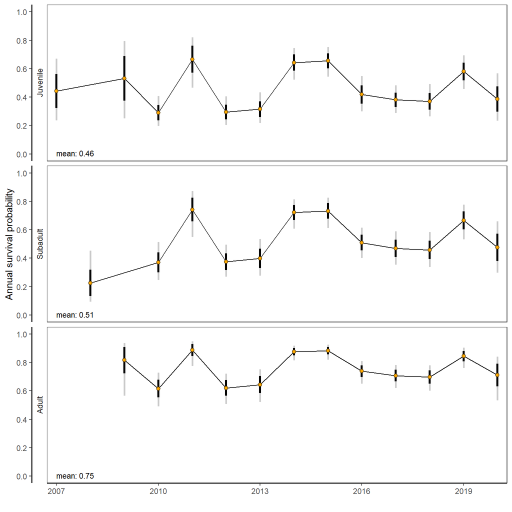

```r
## Format and simplify
## -----------------------------------------------------------------------------
df.S.age <- lapply(rownames(S.mod.avg), function(row) {
  x <- stringr::str_split(row, " ")[[1]]
  data.frame(parameter = x[1],
             cohort = substr(x[3], 2, nchar(x[3])),
             year = as.numeric(substr(x[5], 2, nchar(x[5]))))
}) %>%
  do.call("rbind",.) %>%
  cbind(S.mod.avg) %>%
  mutate(ageclass = case_when(
    age == 0 ~ 'Juvenile',
    age == 1 ~ 'Subadult',
    age %in% 2:13 ~ 'Adult'
  )) %>%
  mutate(ageclass = factor(ageclass, levels = c("Juvenile", "Subadult", "Adult"))) %>%
  ## round mean, Se and CI values at fifth decimal to remove redundant values
  subset(., select = c(year, estimate, se, lcl, ucl, ageclass)) %>%
  mutate(estimate = round(estimate, 6)) %>%
  mutate(se = round(se, 6)) %>%
  mutate(lcl = round(lcl, 6)) %>%
  mutate(ucl = round(ucl, 6)) %>%
  unique.data.frame()

## Estimate means for age-classes
## ---------------------------------------------------------------
df.annotation <- df.S.age %>%
  group_by(ageclass) %>%
  summarise(
    Median = median(estimate),
    mean  = mean(estimate),
    Min = min(estimate),
    Max = max(estimate),
    N = length(estimate),
    SD = stats::sd(estimate)) %>%
  mutate(SE = SD/sqrt(N))

## Create plot of age-specific survival rates
## -----------------------------------------------------------------------------
p.age <-
    ggplot(df.S.age,
           aes(x = year, y = estimate)) +
    geom_errorbar(aes(ymin = lcl, ymax = ucl) ,
                colour = "grey80", size = 1, width = 0) +
    geom_errorbar(aes(ymin = estimate - se, ymax = estimate + se) ,
                colour = "black", size = 1.2, width = 0) +
    geom_line() +
    geom_point(color = "black", fill = "Orange", size = 1.75, shape = 21) +
    theme_article() +
    theme(
      # panel.grid.major.y = element_line(colour = "grey90", size = 0.5),
      # panel.grid.minor.y = element_line(colour = "grey90", size = 0.5),
      axis.line = element_line(size = .7, color = "black"),
      legend.background = element_rect(fill = NA, colour = NA),
      legend.margin = margin(c(1,1,1,1)),
      legend.direction = "horizontal",
      legend.position = "none",
      legend.justification = c(1,1),
      panel.background = element_rect(fill = NA),
      panel.border = element_rect(fill = NA)) +
    scale_color_brewer(palette = "Set1",
                       name = "") +
    scale_y_continuous(breaks = seq(0, 1, .2), limits = c(0, 1)) +
    scale_x_continuous(breaks = seq(2007, 2020, 3), expand = c(0.02,0.02)) +
    xlab("") +
    ylab("Annual survival probability") +
    facet_wrap(~ageclass, ncol = 1, strip.position = "left") +
    geom_text(data = df.annotation, x = 2007, y = -Inf,
      hjust   = 0, vjust   = -0.8, col = "Black", size = 3,
      aes(label = paste0("mean: ",round(mean,2))))
p.age
```

Mean estimates for age and sex combinations over time:

```r
## Age-specific means
## -----------------------------------------------------------------------------
df.S.age %>%
  group_by(ageclass) %>%
  summarise(Mean = round(mean(estimate),2),
            Mean.SE = round(sd(estimate)/sqrt(length(estimate)),2),
            Min = round(min(estimate), 2),
            Max = round(max(estimate), 2),
            .groups = "keep") %>%
  as.data.frame()
```

```
#>   ageclass Mean Mean.SE  Min  Max
#> 1 Juvenile 0.46    0.04 0.29 0.67
#> 2 Subadult 0.51    0.05 0.23 0.74
#> 3    Adult 0.75    0.03 0.62 0.89
```

##### NAO

Visualise correlation between survival and climate indices (NAO, as used in the models and Snow cover as further descriptive measure)

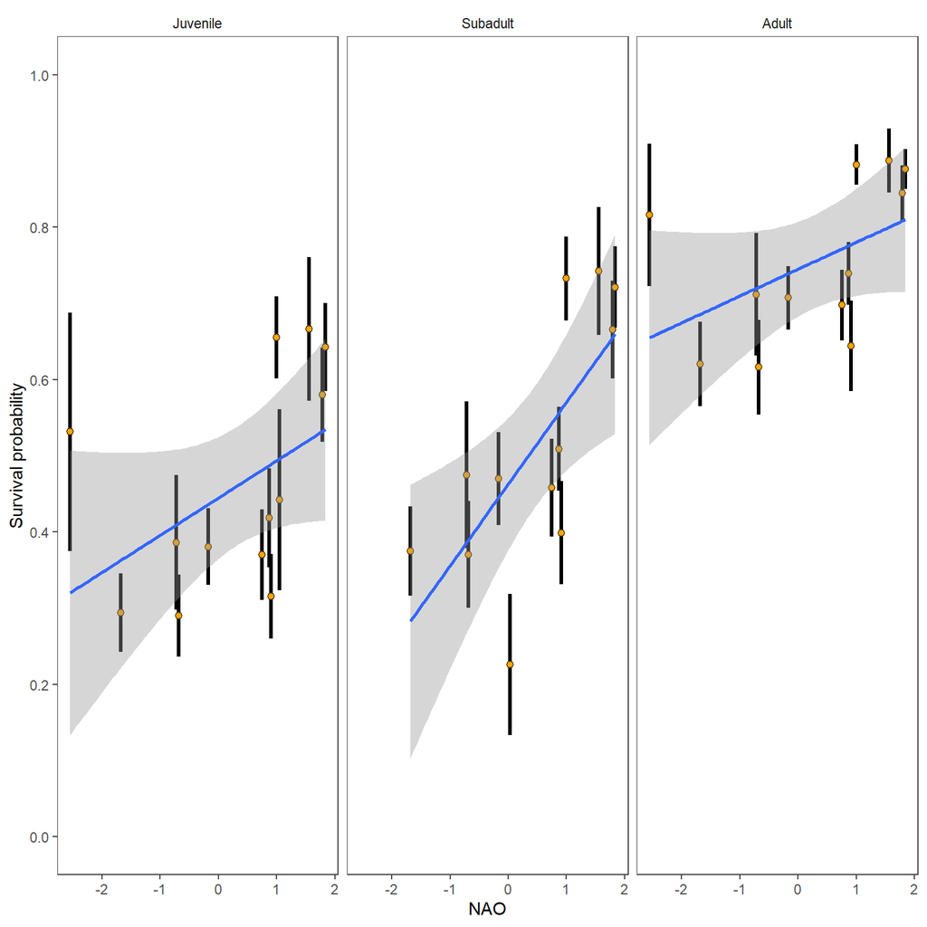

```r
## Join survival rates and climate data based on sampling year
## -----------------------------------------------------------------------------
df <- data.frame(year = as.numeric(as.character(nao$time)), NAO = nao$DJFM, SNOW = nao$snow) %>%
  filter(., year > 2006) %>%
  left_join(., df.S.age)

## Create Figure S2
## -----------------------------------------------------------------------------
Fig_S2 <- ggplot(df, aes(x = NAO, y = estimate, group = ageclass)) +
  geom_errorbar(aes(ymin = estimate - se, ymax = estimate + se) ,
                colour = "black", size = 1.2, width = 0) +
  geom_point(color = "black", fill = "Orange", size = 1.75, shape = 21) +
  geom_smooth(method = "lm", se = T, formula = "y ~ x") +
  theme_article() +
  facet_wrap(~ageclass) +
  xlab("NAO") +
  ylab("Survival probability") +
  scale_y_continuous(breaks = seq(0, 1, .2), limits = c(0, 1))
Fig_S2
```

```r
ggsave(plot = Fig_S2, filename = "plots/Fig_S2.pdf",
       device = "pdf", dpi = 1200, width = 6, height = 4, units = "in")
ggsave(plot = Fig_S2, filename = "plots/Fig_S2.png",
       device = "png", dpi = 1200, width = 6, height = 4, units = "in")
```

Compute pearson correlation coefficients for each age class

```r
## Juveniles
## -----------------------------------------------------------------------------
cor.test(df$estimate[df$ageclass == "Juvenile"],
         df$NAO[df$ageclass == "Juvenile"],
         method = "pearson")
```

```
#>
#>  Pearson's product-moment correlation
#>
#> data:  df$estimate[df$ageclass == "Juvenile"] and df$NAO[df$ageclass == "Juvenile"]
#> t = 1.8118, df = 11, p-value = 0.09738
#> alternative hypothesis: true correlation is not equal to 0
#> 95 percent confidence interval:
#>  -0.09727225  0.81508957
#> sample estimates:
#>       cor
#> 0.4794072
## Subadults
## -----------------------------------------------------------------------------
```

```r
cor.test(df$estimate[df$ageclass == "Subadult"],
         df$NAO[df$ageclass == "Subadult"],
         method = "pearson")
```

```
#>
#>  Pearson's product-moment correlation
#>
#> data:  df$estimate[df$ageclass == "Subadult"] and df$NAO[df$ageclass == "Subadult"]
#> t = 3.1783, df = 10, p-value = 0.009847
#> alternative hypothesis: true correlation is not equal to 0
#> 95 percent confidence interval:
#>  0.2275831 0.9118312
#> sample estimates:
#>       cor
#> 0.7088956
## Adults
## -----------------------------------------------------------------------------
```

```r
cor.test(df$estimate[df$ageclass == "Adult"],
         df$NAO[df$ageclass == "Adult"],
         method = "pearson")
```

```
#>
#>  Pearson's product-moment correlation
#>
#> data:  df$estimate[df$ageclass == "Adult"] and df$NAO[df$ageclass == "Adult"]
#> t = 1.7296, df = 10, p-value = 0.1144
#> alternative hypothesis: true correlation is not equal to 0
#> 95 percent confidence interval:
#>  -0.1297902  0.8262230
#> sample estimates:
#>       cor
#> 0.4798542
```

Create Figure 1:

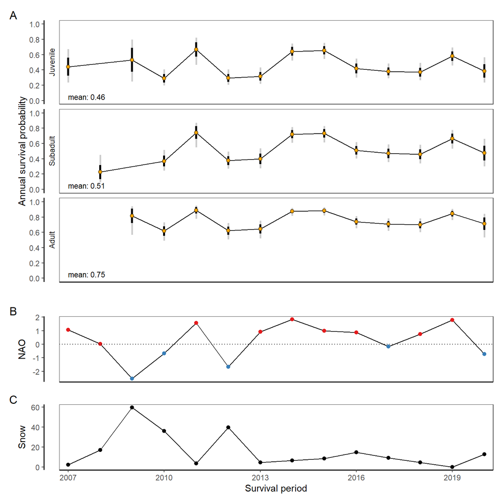

```r
nao$sign <- ifelse(nao$DJFM > 0, "+", "-")
p.nao <-
    ggplot(filter(nao, year > 2007),
           aes(x = year - 1, y = DJFM, col = sign)) +
    geom_line(col = "black") +
    geom_point(size = 1.75) +
    theme_article() +
    theme(
      legend.position = "none",
      axis.line = element_line(size = .7, color = "black"),
      panel.background = element_rect(fill = NA),
      panel.border = element_rect(fill = NA)) +
    scale_x_continuous(breaks = seq(2007, 2020, 3), expand = c(0.02,0.02)) +
    scale_color_brewer(palette = "Set1",direction = -1) +
    geom_hline(yintercept = 0, lty = "dotted") +
    xlab("Survival period") +
    ylab("NAO")

p.snow <-
  ggplot(filter(nao, year > 2007),
         aes(x = year - 1, y = snow)) +
  geom_line(col = "black") +
  geom_point(size = 1.75) +
  theme_article() +
  theme(
    legend.position = "none",
    axis.line = element_line(size = .7, color = "black"),
    panel.background = element_rect(fill = NA),
    panel.border = element_rect(fill = NA)) +
  scale_x_continuous(breaks = seq(2007, 2020, 3), expand = c(0.02,0.02)) +
  scale_color_brewer(palette = "Set1",direction = -1) +
  xlab("Survival period") +
  ylab("Snow")

p.temp <-
  ggplot(filter(nao, year > 2007),
         aes(x = year - 1, y = temp)) +
  geom_line(col = "black") +
  geom_point(size = 1.75) +
  theme_article() +
  theme(
    legend.position = "none",
    axis.line = element_line(size = .7, color = "black"),
    panel.background = element_rect(fill = NA),
    panel.border = element_rect(fill = NA)) +
  scale_x_continuous(breaks = seq(2007, 2020, 3), expand = c(0.02,0.02)) +
  scale_color_brewer(palette = "Set1",direction = -1) +
  xlab("Survival period") +
  ylab("Mean emperature [°C]")

Fig_1 <- (p.age + theme(axis.text.x = element_blank(),
               axis.ticks.x = element_blank())) +
  (p.nao + theme(axis.text.x = element_blank(),
                 axis.title.x = element_blank(),
                 axis.ticks.x = element_blank())) +
  p.snow +
  plot_layout(ncol = 1, heights = c(4, 1,1)) +
  plot_annotation(tag_levels = "A")
Fig_1
```

```r
ggsave(plot = Fig_1, filename = "plots/Fig_1.pdf",
        device = "pdf", dpi = 1200, width = 6, height = 6, units = "in")
ggsave(plot = Fig_1, filename = "plots/Fig_1.png",
        device = "png", dpi = 1200, width = 6, height = 6, units = "in")
```

##### Body Condition

Explore correlations between survival estimates and body condition indices:

```r
## Select parameter indices to compute real estimates, skip year 2008 as
## this cohort is missing
## -----------------------------------------------------------------------------
par.index <- filter(ddl.barker$S, time != "2008",
                    Sex == "Female", age == "[0,1)", Morph == "D", Lbinom == "Uninfected")

## Get the range of covariate values from the raw data
## -----------------------------------------------------------------------------
BCI.values = c(seq(from = min(dp.barker$data$BCI), to = max(dp.barker$data$BCI), length.out = 30), 0)

## Compute real estimates
## -----------------------------------------------------------------------------
BCI.reals <- covariate.predictions(
  supported.models.barker,
  data = data.frame(
    BCI = BCI.values),
  indices = par.index$par.index,
  drop = T)[["estimates"]] %>%
  left_join(., par.index[,c("par.index", "age", "time")], by = "par.index")

## Create figure
## -----------------------------------------------------------------------------
p.BCI.time <- lapply(unique(BCI.reals$time), function(x) {
  ggplot(filter(BCI.reals, time == x), aes(x = covdata, y = estimate, group = age)) +
    geom_ribbon(aes(ymin = lcl, ymax = ucl), fill = "#9ecae1") +
    geom_ribbon(aes(ymin = estimate - se, ymax = estimate + se), fill = "#3182bd") +
    geom_line(size = 1) +
    theme_article() +
    theme(axis.line = element_line(size = .7, color = "black"),
          axis.title = element_blank(),
          axis.text = element_blank(),
          axis.ticks = element_blank(),
          panel.background = element_rect(fill = NA),
          panel.border = element_rect(fill = NA),
          text = element_text(size = 10)) +
    scale_x_continuous(expand = c(0,0)) +
    scale_y_continuous(limits = c(0,1), expand = c(0,0)) +
    labs(title = x)
}) %>%
  set_names(., unique(BCI.reals$time))
```

The model averaged estimates above show that the relationship between estimates survival and body condition is parallel across years. For simplicity, estimates are derived from a time-independent model to average across years:

```r
## Compute real estimates from a time-invariant model
## -----------------------------------------------------------------------------
BCI.reals <- covariate.predictions(
  models.barker.adj$model.225,
  data = data.frame(
    BCI = BCI.values),
  indices = par.index$par.index,
  drop = T)[["estimates"]] %>%
  left_join(., par.index[,c("par.index", "age", "time")], by = "par.index")

## predicted increase from lowest to highes score
## -----------------------------------------------------------------------------
range(BCI.reals$estimate)
```

```
#> [1] 0.2410185 0.6477331
```

```r
coef <- summary(lm(estimate ~ covdata, BCI.reals))
coef$coefficients[2,2]
```

```
#> [1] 8.96781e-05
## Create plot
## -----------------------------------------------------------------------------
```

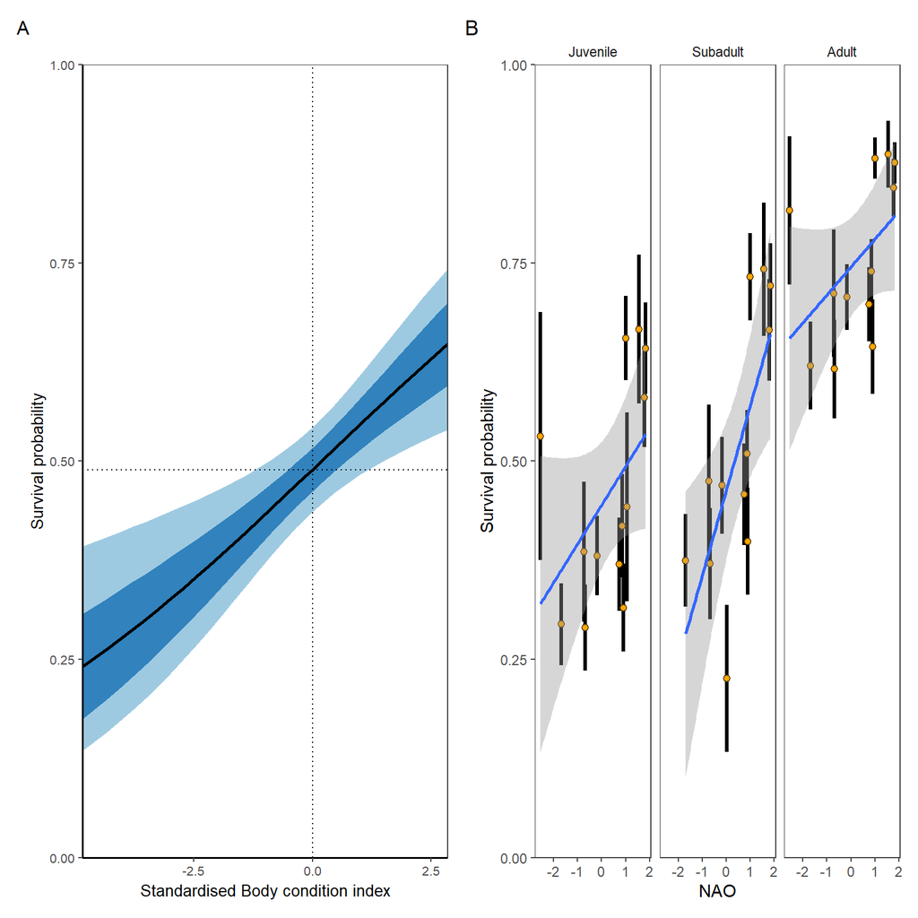

```r
p.BCI <-
    ggplot(BCI.reals, aes(x = covdata, y = estimate, group = age)) +
    geom_ribbon(aes(ymin = lcl, ymax = ucl), fill = "#9ecae1") +
    geom_ribbon(aes(ymin = estimate - se, ymax = estimate + se), fill = "#3182bd") +
    geom_line(size = 1) +
    theme_article() +
    theme(axis.line = element_line(size = .7, color = "black"),
          panel.background = element_rect(fill = NA),
          panel.border = element_rect(fill = NA),
          text = element_text(size = 10)) +
    scale_x_continuous(expand = c(0,0)) +
    scale_y_continuous(limits = c(0,1), expand = c(0,0)) +
    geom_vline(xintercept = 0, lty = "dotted") +
    geom_hline(yintercept = BCI.reals$estimate[BCI.reals$covdata == 0][1], lty = "dotted") +
    xlab("Standardised Body condition index") +
    ylab("Survival probability")

## Assemble multi-panel figure, Figure 2 in the paper
## -----------------------------------------------------------------------------
# col1 <- (p.BCI.time$`2007`/p.BCI.time$`2009`/p.BCI.time$`2010`/p.BCI.time$`2011`/p.BCI.time$`2012`)
# col2 <- (p.BCI.time$`2013`/p.BCI.time$`2014`/p.BCI.time$`2015`/p.BCI.time$`2016`/p.BCI.time$`2017`)
# col3 <- (p.BCI.time$`2018` + p.BCI.time$`2019` + p.BCI.time$`2020`) /
#   p.BCI + plot_layout(widths = c(rep(1,3), 3), heights = c(rep(0.5, 1), 3))
# Fig_2 <- (col1 | col2 | col3) + plot_layout(widths = c(.85,0.85,3))
# Fig_2

Fig_2_new <-
  (p.BCI +
     scale_y_continuous(limits = c(0,1), expand = c(0,0)) +
     labs(tag = "A")) +
  (Fig_S2 +
     scale_y_continuous(limits = c(0,1), expand = c(0,0)) +
     labs(tag = "B"))
Fig_2_new
```

```r
ggsave(plot = Fig_2_new, filename =  "plots/Fig_2.pdf",
        device = "pdf", dpi = 1200, width = 6, height = 6, units = "in")
ggsave(plot = Fig_2_new, filename = "plots/Fig_2.png",
        device = "png", dpi = 1200, width = 6, height = 6, units = "in")
```

##### Resighting rates (R)

Explore re-sighting rates:

```r
## obtain estimates
## -----------------------------------------------------------------------------
df.R <- lapply(rownames(R.mod.avg), function(row) {
  x <- stringr::str_split(row, " ")[[1]]
  data.frame(parameter = x[1],
             cohort = substr(x[3], 2, nchar(x[3])),
             year = as.numeric(substr(x[5], 2, nchar(x[5]))))
}) %>%
  do.call("rbind",.) %>%
  cbind(R.mod.avg) %>%
  mutate(ageclass = case_when(
    age == 0 ~ 'Y1',
    age == 1 ~ 'Y2',
    age == 2 ~ 'Y3',
    age %in% 3:13 ~ 'Y4+'
  )) %>%
  filter(., cohort == 2007, Sex == "Female")

## Linear regression of p on year
## -----------------------------------------------------------------------------
lm.mod <- lm(estimate ~ year, data = df.R) %>%
  summary()

## range
## -----------------------------------------------------------------------------
range(df.R$estimate)
```

```
#> [1] 0.1173408 0.5971432
## mean across years
## -----------------------------------------------------------------------------
```

```r
mean(df.R$estimate)
```

```
#> [1] 0.3329647
## Create figure
## -----------------------------------------------------------------------------
```

```r
p.res <-
  ggplot(filter(df.R, cohort == 2007), aes(x = year, y = estimate)) +
  geom_smooth(method = "lm", se = T, level = .95) +
  geom_errorbar(aes(ymin = lcl, ymax = ucl),
                width = 0., size = 1, col = "grey50") +
  geom_errorbar(aes(ymin = estimate - se, ymax = estimate + se),
                width = 0., size = 1.2) +
  geom_point(size = 2, shape = 21, col = "black", fill = "orange") +
  theme_article() +
  theme(
    axis.line = element_line(size = .7, color = "black"),
    legend.position = "none",
    panel.background = element_rect(fill = NA),
    panel.border = element_rect(fill = NA)) +
    scale_x_continuous(breaks = seq(2007, 2020, 3),
                       expand = c(0,0),
                       limits = c(2006.8, 2020.2)) +
    xlab("") +
    ylab("Live resighting rate (R)") +
    scale_y_continuous(breaks = seq(0, 0.6, 0.1)) +
    annotate("text", x = 2007 , y = Inf, hjust = 0, vjust = 1.5,
             label = paste0("adj. R²: ", round(lm.mod$adj.r.squared,3),
                            "\np < 0.001"))
```

##### Resigthting rates (R’)

Explore parameter R’:

```r
## Only a single unique estimate
## -----------------------------------------------------------------------------
RPrime.mod.avg[,c("estimate", "se")] %>%
  unique.data.frame()
```

```
#>                                     estimate         se
#> R' gFemaleDInfected c2007 a0 t2007 0.1033966 0.01904121
```

##### Recovery chances (r)

Explore recovery chances:

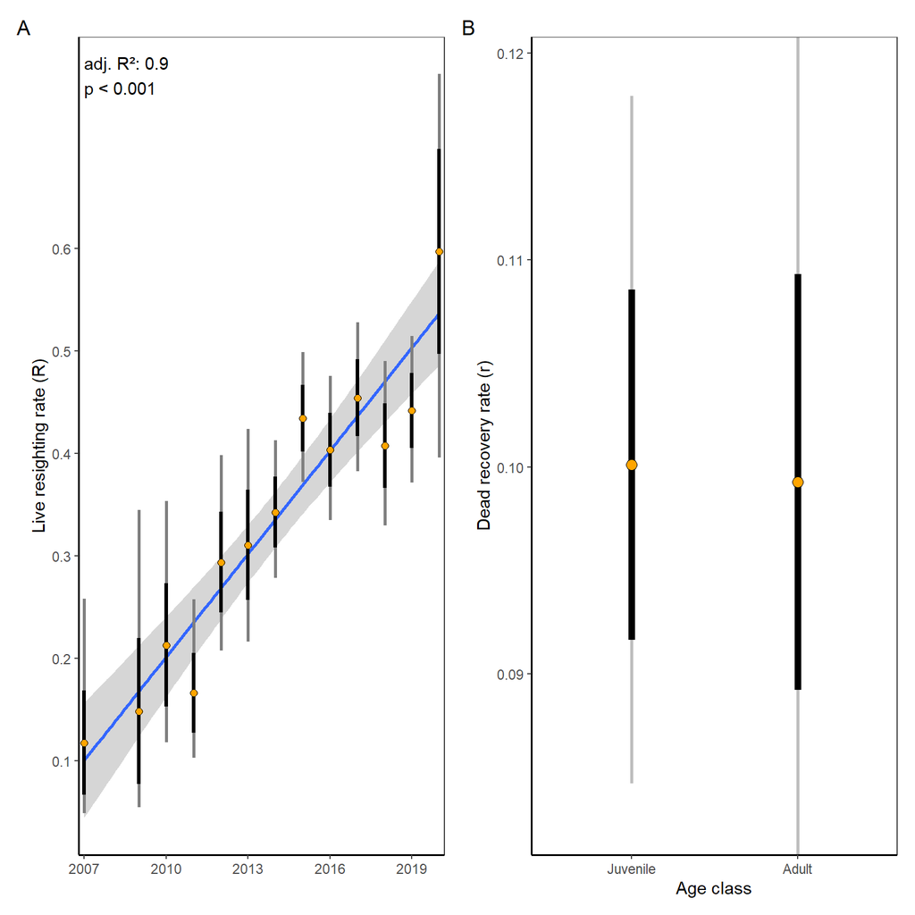

```r
##  simplify model output
## -----------------------------------------------------------------------------
df.r <- lapply(rownames(r.mod.avg), function(row) {
  x <- stringr::str_split(row, " ")[[1]]
  data.frame(parameter = x[1],
             cohort = substr(x[3], 2, nchar(x[3])),
             age = substr(x[4], 2, nchar(x[4])),
             year = as.numeric(substr(x[5], 2, nchar(x[5]))))
}) %>%
  do.call("rbind",.) %>%
  cbind(r.mod.avg) %>%
  subset(., select = c(estimate, se, lcl, ucl, age, Sex, cohort)) %>%
  filter(., Sex == "Female", age %in% 0:1)
df.r$age <- ifelse(df.r$age == "0", "Juvenile", "Adult") %>%
  factor(levels = c("Juvenile", "Adult"))

## Create figure
## -----------------------------------------------------------------------------
p.recov <- ggplot(df.r,
                   aes(x = age, y = estimate)) +
    geom_errorbar(aes(ymin = lcl, ymax = ucl), width = 0, size = 1, col = "Grey") +
    geom_errorbar(aes(ymin = estimate - se, ymax = estimate + se),
                  width = 0, size = 2, col = "black") +
    geom_point(size = 3, shape = 21, colour = "black", fill = "orange") +
    theme_article() +
    theme(
      axis.line = element_line(size = .7, color = "black"),
      panel.background = element_rect(fill = NA),
      panel.border = element_rect(fill = NA)) +
    scale_y_continuous(expand = c(0,0), breaks = seq(0, 0.2,0.01)) +
    xlab("Age class") +
    ylab("Dead recovery rate (r)")

## Assemble plot, same as Figure 3 in the paper
## -----------------------------------------------------------------------------
Fig_3 <- p.res + p.recov + plot_annotation(tag_levels = "A")
Fig_3
```

```r
ggsave(plot = Fig_3, filename =  "plots/Fig_3.pdf",
       device = "pdf", dpi = 1200, width = 6, height = 4, units = "in")
ggsave(plot = Fig_3, filename = "plots/Fig_3.png",
       device = "png", dpi = 1200, width = 6, height = 4, units = "in")
```

## Known-fates

As additional analysis, we compared individuals which were known to have died during the first year of life with individuals that were re-sighted at least once after completing the first year of life.

```r
## Load raw data and merge ranks 4 and 5 to a single category
## -----------------------------------------------------------------------------
ringing_data <- as.data.frame(read_csv("data/ringing_data.csv")) %>%
  mutate(Rank = factor(case_when(
    Rank == 1 ~ "1",
    Rank == 2 ~ "2",
    Rank == 3 ~ "3",
    Rank >= 4 ~ "4/5")))

## Query re-sighting data to identify individuals that are known
## to have survived at least until reaching sub-adulthood
resighting_data <- as.data.frame(read_csv("data/resighting_data.csv")) %>%
  filter(Ring %in% ringing_data$Ring)

## Identify individuals that did before reaching the second year of life
## -----------------------------------------------------------------------------
dead <-
  filter(ringing_data,
         Dead == 'Yes') %>%
  mutate(HatchingDate = as.Date(paste0(Year - 1, "-12-31")) + Hatch) %>%
  mutate(DaysSinceHatching = as.Date(DateDeath) - HatchingDate) %>%
  mutate(CauseDeath = case_when(
    CauseDeath == "Car collision" ~ "Collision",
    CauseDeath == "Train collision" ~ "Collision",
    CauseDeath == "Trichomonias infection" ~ "Trichomoniasis",
    TRUE ~ CauseDeath)) %>%
  filter(., DaysSinceHatching <= 365)
```

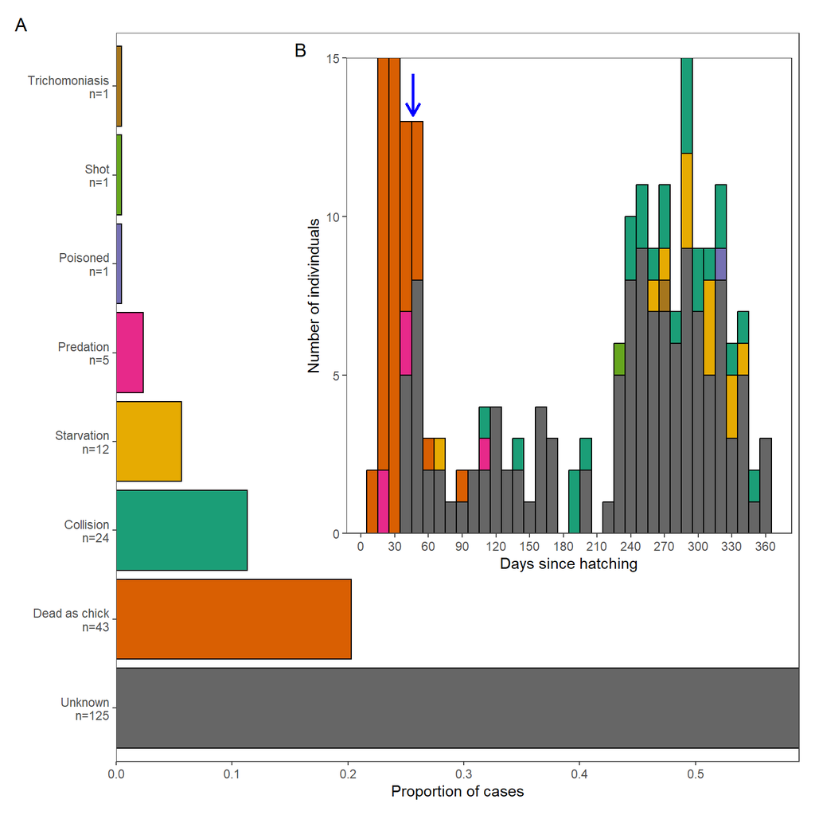

```r
## Format data of know deaths
## -----------------------------------------------------------------------------
dead[["CauseDeath"]][is.na(dead[["CauseDeath"]])] <- "Unknown"
death_causes <- as.data.frame(table(dead$CauseDeath))
death_causes[["label"]] <- paste0(death_causes[["Var1"]], "\n", "n=", death_causes[["Freq"]])
death_causes[["label"]] <- factor(
  death_causes[["label"]],
  levels = death_causes[["label"]][order(death_causes$Freq, decreasing = T)])

## Create figure summarising causes of death
## -----------------------------------------------------------------------------
p.CauseDeath <-
ggplot(death_causes, aes(x = label, y = Freq/sum(Freq), fill = Var1)) +
  geom_bar(stat = "identity", col = "Black") +
  theme_article() +
  theme(legend.position = "none", axis.title.y = element_blank()) +
  ylab("Proportion of cases") +
  # labs(subtitle = "Causes of death (n = 198)", tag = "A") +
  scale_fill_brewer(palette = "Dark2") +
  scale_y_continuous(expand = c(0,0)) +
  coord_flip()

## Plot time of death within first year as a histogram
## -----------------------------------------------------------------------------
p.TimeDeath <-
  ggplot(dead, aes(x = DaysSinceHatching, fill = CauseDeath)) +
  geom_histogram(binwidth = 10, col = "Black") +
  theme_article() +
  theme(legend.position = "none") +
  xlab("Days since hatching") +
  ylab("Number of indivinduals") +
  geom_segment(
    data.frame(DaysSinceHatching = 46, CauseDeath = NA), mapping = aes(
      x = DaysSinceHatching, xend = DaysSinceHatching,
      y = 14.5, yend = 13.2), arrow = arrow(length = unit(0.35, "cm")),
                                            size = 1, color = "blue") +
  # annotate("text", x = 47, y = Inf, vjust = 1.5, hjust = 0, label = "Mean fledging date") +
  scale_y_continuous(expand = c(0,0)) +
  scale_x_continuous(breaks = seq(0, 365, 30)) +
  scale_fill_brewer(palette = "Dark2")

## Create Supplementary figure S3
## -----------------------------------------------------------------------------
Fig_S3 <- p.CauseDeath + inset_element(p.TimeDeath, 0.25, 0.25, 1, 1) +
    plot_annotation(tag_levels = 'A')
Fig_S3
```

```r
ggsave(plot = Fig_S3, filename = "plots/Fig_S3.pdf",
       device = "pdf", dpi = 1200, width = 9, height = 6, units = "in")
ggsave(plot = Fig_S3, filename = "plots/Fig_S3.png",
       device = "png", dpi = 1200, width = 9, height = 6, units = "in")
```

### Binomal mixed model

Compile dataset to analyse first year survival using a linear mixed model

```r
## Identify individuals that did reach the second year of life
## -----------------------------------------------------------------------------
alive <- filter(resighting_data,
                DaysSinceHatching > 365) %>%
  .[["Ring"]] %>% unique()

## Set-up data frame
## -----------------------------------------------------------------------------
df <- data.frame(Ring = c(dead[["Ring"]], alive),
                 Group = c(rep("Dead", nrow(dead)),
                           rep("Alive", length(alive)))) %>%
  left_join(., ringing_data, by = "Ring") %>%
  mutate(survival = ifelse(Group == "Dead", 0, 1)) %>%
  mutate(Leucocytozoon = ifelse(Lprev == 0, "Uninfected", "Infected")) %>%
  mutate(Hatch = scale(Hatch)) %>%
  mutate(Age = scale(Age_days)) %>%
  mutate(BCI = scale(BCI)) %>%
  left_join(., data.frame(Year = as.numeric(as.character(nao$time)),
                          NAO = nao$DJFM), by = "Year")
```

Analysis of survival probabilities using GLMMs:

```r
## Full model including all individuals
## -----------------------------------------------------------------------------
model.1 <- glmer(survival ~ Leucocytozoon + Age + BCI + Rank + Hatch + NAO +
                   (1|Year) + (1|Brood_ID),
                 data = df, family = "binomial", control = glmerControl("bobyqa"))

## Reduced model by excluding certain mortality causes
## -----------------------------------------------------------------------------
df2 <- filter(df, survival == 0,
              !CauseDeath %in% c("Car collision", "Poisoned", "Predation",
                                 "Shot", "Train collision", "Dead as chick"))
df2 <- rbind(df2, filter(df, survival == 1))
model.2 <- glmer(survival ~ Leucocytozoon + Age + BCI + Rank + Hatch + NAO +
                   (1|Year) + (1|Brood_ID),
                 data = df2,
                 family = "binomial")

## Plot model summaries
## -----------------------------------------------------------------------------
tab_model(model.1, model.2,
          show.stat = T, string.stat = "t", show.reflvl = T,
          title = "Binomial models predicting first year survival")
```

Binomial models predicting first year survival

|  | survival |  |  |  | survival |  |  |  |
| --- | --- | --- | --- | --- | --- | --- | --- | --- |
| Predictors | Odds Ratios | CI | t | p | Odds Ratios | CI | t | p |
| (Intercept) | 2.04 | 0.98 – 4.28 | 1.90 | 0.058 | 3.43 | 1.54 – 7.65 | 3.01 | **0.003** |
| Age | 1.37 | 1.07 – 1.77 | 2.45 | **0.014** | 1.12 | 0.83 – 1.51 | 0.72 | 0.472 |
| BCI | 1.73 | 1.39 – 2.17 | 4.82 | **<0.001** | 1.33 | 1.05 – 1.68 | 2.38 | **0.017** |
| Hatch | 0.78 | 0.59 – 1.04 | -1.68 | 0.093 | 1.01 | 0.73 – 1.41 | 0.08 | 0.936 |
| LeucocytozoonUninfected | 1.03 | 0.67 – 1.59 | 0.15 | 0.881 | 0.98 | 0.61 – 1.58 | -0.09 | 0.932 |
| NAO | 1.56 | 0.95 – 2.57 | 1.76 | 0.079 | 1.85 | 1.08 – 3.17 | 2.25 | **0.024** |
| 1 | *Reference* |  |  |  | *Reference* |  |  |  |
| 2 | 1.12 | 0.70 – 1.80 | 0.48 | 0.633 | 0.82 | 0.48 – 1.41 | -0.70 | 0.481 |
| 3 | 0.68 | 0.38 – 1.23 | -1.27 | 0.203 | 0.37 | 0.19 – 0.73 | -2.89 | **0.004** |
| 4/5 | 1.94 | 0.47 – 8.05 | 0.91 | 0.361 | 1.14 | 0.25 – 5.07 | 0.17 | 0.866 |
| Random Effects |  |  |  |  |  |  |  |  |
| σ<sup>2</sup> | 3.29 |  |  |  | 3.29 |  |  |  |
| τ<sub>00</sub> | 0.24 <sub>Brood_ID</sub> |  |  |  | 0.00 <sub>Brood_ID</sub> |  |  |  |
|  | 1.20 <sub>Year</sub> |  |  |  | 1.40 <sub>Year</sub> |  |  |  |
| ICC | 0.30 |  |  |  | 0.30 |  |  |  |
| N | 13 <sub>Year</sub> |  |  |  | 13 <sub>Year</sub> |  |  |  |
|  | 587 <sub>Brood_ID</sub> |  |  |  | 528 <sub>Brood_ID</sub> |  |  |  |
| Observations | 710 |  |  |  | 639 |  |  |  |
| Marginal R<sup>2</sup> / Conditional R<sup>2</sup> | 0.181 / 0.430 |  |  |  | 0.150 / 0.403 |  |  |  |

```r
## Write to html file --> Table 3 in the paper
## -----------------------------------------------------------------------------
tab_model(model.1, model.2, show.stat = T, string.stat = "t", show.reflvl = T,
          file = "plots/BinomialModel.html", title = "Binomial models predicting first year survival")
```

Binomial models predicting first year survival

|  | survival |  |  |  | survival |  |  |  |
| --- | --- | --- | --- | --- | --- | --- | --- | --- |
| Predictors | Odds Ratios | CI | t | p | Odds Ratios | CI | t | p |
| (Intercept) | 2.04 | 0.98 – 4.28 | 1.90 | 0.058 | 3.43 | 1.54 – 7.65 | 3.01 | **0.003** |
| Age | 1.37 | 1.07 – 1.77 | 2.45 | **0.014** | 1.12 | 0.83 – 1.51 | 0.72 | 0.472 |
| BCI | 1.73 | 1.39 – 2.17 | 4.82 | **<0.001** | 1.33 | 1.05 – 1.68 | 2.38 | **0.017** |
| Hatch | 0.78 | 0.59 – 1.04 | -1.68 | 0.093 | 1.01 | 0.73 – 1.41 | 0.08 | 0.936 |
| LeucocytozoonUninfected | 1.03 | 0.67 – 1.59 | 0.15 | 0.881 | 0.98 | 0.61 – 1.58 | -0.09 | 0.932 |
| NAO | 1.56 | 0.95 – 2.57 | 1.76 | 0.079 | 1.85 | 1.08 – 3.17 | 2.25 | **0.024** |
| 1 | *Reference* |  |  |  | *Reference* |  |  |  |
| 2 | 1.12 | 0.70 – 1.80 | 0.48 | 0.633 | 0.82 | 0.48 – 1.41 | -0.70 | 0.481 |
| 3 | 0.68 | 0.38 – 1.23 | -1.27 | 0.203 | 0.37 | 0.19 – 0.73 | -2.89 | **0.004** |
| 4/5 | 1.94 | 0.47 – 8.05 | 0.91 | 0.361 | 1.14 | 0.25 – 5.07 | 0.17 | 0.866 |
| Random Effects |  |  |  |  |  |  |  |  |
| σ<sup>2</sup> | 3.29 |  |  |  | 3.29 |  |  |  |
| τ<sub>00</sub> | 0.24 <sub>Brood_ID</sub> |  |  |  | 0.00 <sub>Brood_ID</sub> |  |  |  |
|  | 1.20 <sub>Year</sub> |  |  |  | 1.40 <sub>Year</sub> |  |  |  |
| ICC | 0.30 |  |  |  | 0.30 |  |  |  |
| N | 13 <sub>Year</sub> |  |  |  | 13 <sub>Year</sub> |  |  |  |
|  | 587 <sub>Brood_ID</sub> |  |  |  | 528 <sub>Brood_ID</sub> |  |  |  |
| Observations | 710 |  |  |  | 639 |  |  |  |
| Marginal R<sup>2</sup> / Conditional R<sup>2</sup> | 0.181 / 0.430 |  |  |  | 0.150 / 0.403 |  |  |  |

Plots model predictions:

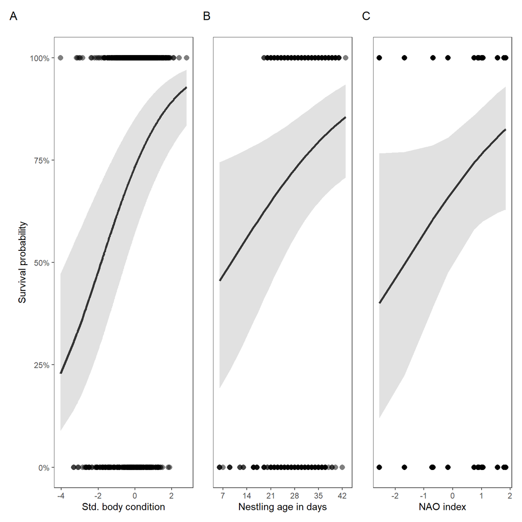

```r
## Predictions for body condition
## -----------------------------------------------------------------------------
pred.cond <- plot_model(model.1, type = "pred", terms = "BCI [all]", title = "",
                        ci.lvl = 0.95, show.data = T, line.size = 1.22,
                        colors = 'gs') +
  theme_article() +
  xlab("Std. body condition") +
  ylab("Survival probability") +
  labs(tag = "A")

pred.nao <- plot_model(model.1, type = "pred", terms = "NAO [all]", title = "",
                       ci.lvl = 0.95, show.data = T, line.size = 1.22,
                       colors = 'gs') +
  theme_article() +
  xlab("NAO index") +
  theme(axis.ticks.y = element_blank(),
        axis.title.y = element_blank(),
        axis.text.y = element_blank()) +
  labs(tag = "C")

## Predictions for interaction Leucocytozoon with Age
## -----------------------------------------------------------------------------
pred.leuco <-
  plot_model(model.1, type = "pred", terms = "Age [all]",
             title = "", ci.lvl = 0.95, show.data = T,
             line.size = 1.22, colors = 'gs') +
  theme_article() +
  theme(axis.ticks.y = element_blank(),
        axis.title.y = element_blank(),
        axis.text.y = element_blank(),
        legend.position = c(1, 0.125),
        legend.justification = c(1,0),
        legend.title = element_text(face = "italic")) +
  xlab("Nestling age in days") +
  ylab("Survival probability") +
  scale_color_brewer(palette = "Dark2") +
  scale_fill_brewer(palette = "Dark2") +
  labs(tag = "B")

## transform age back to original scale for easier interpretation
## -----------------------------------------------------------------------------
scale <- attr(df$Age,"scaled:scale"); center <- attr(df$Age,"scaled:center")
x.res <- data.frame(rescaled = seq(7, 49, 7)) %>%
  mutate(scaled = (rescaled - center) / scale)

pred.leuco <- pred.leuco + scale_x_continuous(breaks = x.res$scaled,
                                              labels = x.res$rescaled)

## Create multi-plot figure 4
## -----------------------------------------------------------------------------
Fig_4 <- pred.cond + pred.leuco + pred.nao
Fig_4
```

```r
ggsave(plot = Fig_4, filename = "plots/Fig_4.pdf",
       device = "pdf", dpi = 1200, width = 9, height = 6, units = "in")
ggsave(plot = Fig_4, filename = "plots/Fig_4.png",
       device = "png", dpi = 1200, width = 9, height = 6, units = "in")
```

## Acknowledgements

The implementation for calculating the adjusted $\hat C$ via bootstrapping was based on a modified R code created by Michael J. Conroy (accessed from https://sites.google.com/site/cmrsoftware/lecture-lab-schedule/6---model-fit-and-mmi/methods-for-assessing-fit)

## Appendix

##### Summary of resights

```r
resighting_data <- filter(resighting_data, Ring %in% ringing_data$Ring)
round(table(resighting_data$study_area)/nrow(resighting_data),2)
```

```
#>
#> FALSE  TRUE
#>  0.52  0.48
```

```r
median(resighting_data$Dist2Nest, na.rm = T)
```

```
#> [1] 9.951693
```

```r
sd(resighting_data$Dist2Nest, na.rm = T)
```

```
#> [1] 65.45944
```

```r
median(resighting_data$Dist2Nest[resighting_data$study_area == FALSE], na.rm = T)
```

```
#> [1] 42.8274
```

```r
sd(resighting_data$Dist2Nest[resighting_data$study_area == FALSE], na.rm = T)
```

```
#> [1] 77.89926
```

##### Summarise capture histories by cohorts and years

```r
## Split capture history (ch) into individual occasion
## -----------------------------------------------------------------------------
dat <- sapply(df.barker$ch, stringr::str_split, "", simplify = T) %>%
  do.call("rbind",.) %>%
  apply(.,2,as.numeric) %>%
  set_colnames(rep(c("L", "D"), nchar(df.barker$ch[[1]])/2))

## separate L(ive) and D(ead) occasions.
## L: Here, only releases
## -----------------------------------------------------------------------------
L <- dat[,seq(1, ncol(dat), 2)] %>%
  set_colnames(2007:2020)
sum(L)

## D: '2' denotes live resightings and '1' dead recovery
## -----------------------------------------------------------------------------
D <- dat[,seq(2, ncol(dat), 2)] %>%
  set_colnames(2007:2020)
table(D)

## Create am array to store summary of capture histories
## D: 2 denotes live resighting and 1 dead recovery
## -----------------------------------------------------------------------------
output <- matrix(
  data = 0,
  nrow = length(seq(2007, 2020)),
  ncol = 2 + length(seq(2007, 2020)) + length(seq(2007, 2020))
) %>%
  as.data.frame()
colnames(output) <-
  c("Year", "Releases",
    paste0("L", 2007:2020),
    paste0("D", 2007:2020))
output[1:nrow(output),1] <- 2007:2020

## Go through each capture history and extract releases, recovery and resights
## D: 2 denotes live resighting  and 1 dead recovery
## -----------------------------------------------------------------------------

for (r in 1:nrow(L)) {
  released <- names(which(L[r,] == 1))
  resighted <- names(which(D[r,] == 2))
  dead <- names(which(D[r,] == 1))

  ## add release to table
  output[output$Year == released, "Releases"] <-
    output[output$Year == released, "Releases"] + 1

  if (length(resighted[!is.na(resighted)] > 0)) {
    output[output$Year == released, paste0("L", resighted)] <-
      output[output$Year == released, paste0("L", resighted)] + 1
  }
  if (length(dead[!is.na(dead)] > 0)) {
    output[output$Year == released, paste0("D", dead)] <-
      output[output$Year == released, paste0("D", dead)] + 1
  }
}

## Check that output is correct
## D: 2 denotes live resighting  and 1 dead recovery
## -----------------------------------------------------------------------------
cat("Releases =", sum(output$Releases), "\n")
cat("Recoveries =", sum(output[,17:30]), "\n")
cat("Resights =", sum(output[,3:16]), "\n")

write.csv(output, file = "data/sample.sizes.csv")
```

##### Create image of unique capture histories

To summarise heterogeneity in resighting histories creates image for each cohort

```r
## Get encounter histories
## -----------------------------------------------------------------------------
dat <- sapply(df.barker$ch, stringr::str_split, "", simplify = T) %>%
  do.call("rbind",.) %>%
  apply(.,2,as.numeric) %>%
  set_colnames(rep(c("L", "D"), nchar(df.barker$ch[[1]])/2))

for (i in 1:nrow(dat)) {
## Release --> -1
dat[i, which(dat[i,] == 1)[1]] <- -1
## Resight --> -1
dat[i, which(dat[i,] == 2)] <- -1
## Dead --> 2
dat[i, which(dat[i,] == 1)] <- 2
## all alive to 1
dat[i, which(dat[i,] == -1)] <- 1
}

# png("plots/Fig_S5.png", width = 9, height = 6,
#     units = "in", res = 600)
# par(mfrow = c(3,5))
# for (i in c(2007, 2009:2020)) {
#   cohort <- which(df.barker$Year == i)
#   image(y = 1:nrow(dat[cohort,]),
#       x = seq(2007, 2020.5, 0.5),
#       z = t(dat[cohort,]),
#       col = c("White", "Black", "Red"),
#       xlab = "Ocassion", ylab = "Individuals",
#       main = i)
# }
# dev.off()
```

##### Visualise decay of encounters with age

There is strong decline in the number of re-sightings per age class

```r
## split dead and live
L <- dat[,seq(1, ncol(dat), 2)] %>%
  set_colnames(2007:2020)
D <- dat[,seq(2, ncol(dat), 2)] %>%
  set_colnames(2007:2020)

## time since birth
mat <- matrix(0, nrow = nrow(dat), ncol = 15) %>%
  set_colnames(., seq(-1, 13, 1))
marked <- apply(L, 1, function(x) which(x == 1)[1])

for (i in 1:nrow(dat)) {
mat[i, 1] <- 1
live <- which(D[i,] != 0) - marked[i] + 2
mat[i, live] <- 1
}
colSums(mat)
```

```
#>   -1    0    1    2    3    4    5    6    7    8    9   10   11   12   13
#> 2723  758  369  156  105   74   62   47   23   16    5    6    0    0    0
```

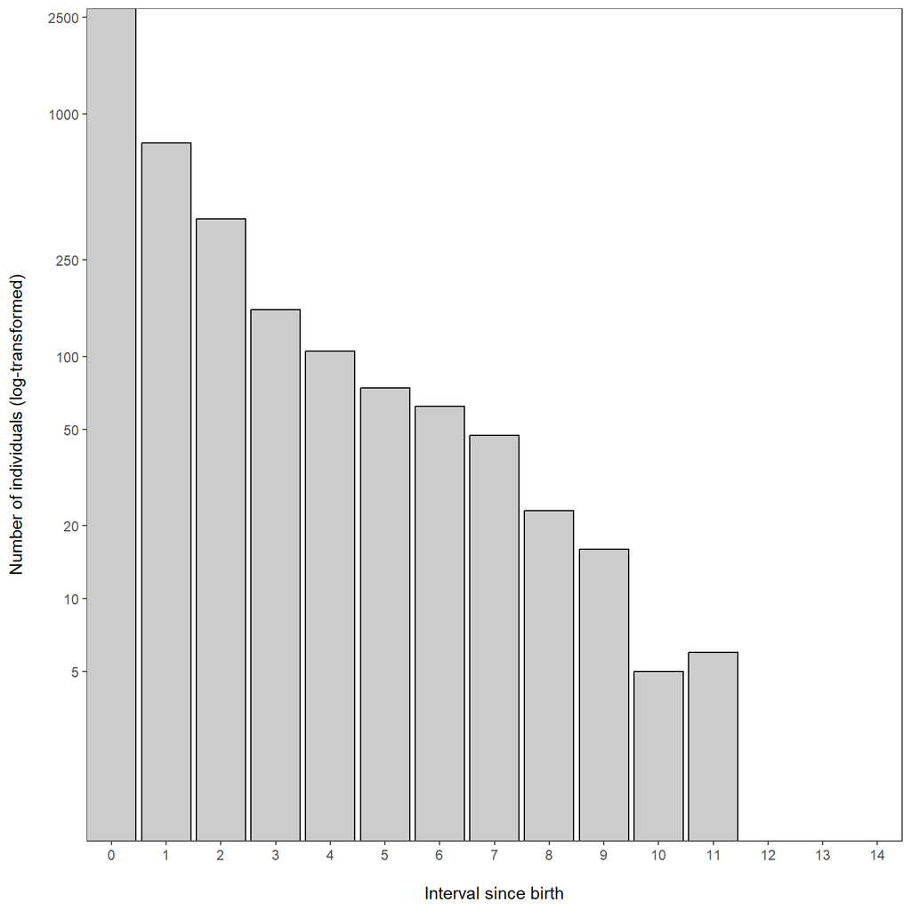

```r
mat <- data.frame(x = colnames(mat) %>% as.numeric(),
                  y = colSums(mat))

Fig_S6 <- ggplot(mat, aes(x = x + 1, y)) +
  geom_bar(stat = "identity", col = "black", fill = "grey80",
           na.rm = T) +
  theme_article() +
  ylab("Number of individuals (log-transformed)\n") +
  xlab("\nInterval since birth") +
  scale_x_continuous(breaks = seq(0, 14, 1), expand = c(0,0)) +
  scale_y_log10(breaks = c(5, 10, 20, 50, 100, 250, 1000, 2500),
                expand = c(0,0))
Fig_S6
```

```r
ggsave(plot = Fig_S6, filename = "plots/Fig_S6.pdf",
       width = 6, height = 6, units = "in", device = "pdf",
       dpi = 1200)
ggsave(plot = Fig_S6, filename = "plots/Fig_S6.png",
       width = 6, height = 6, units = "in", device = "png",
       dpi = 1200)
```

##### Climate variables

Summarise climate variables and association to large scale variation in NAO

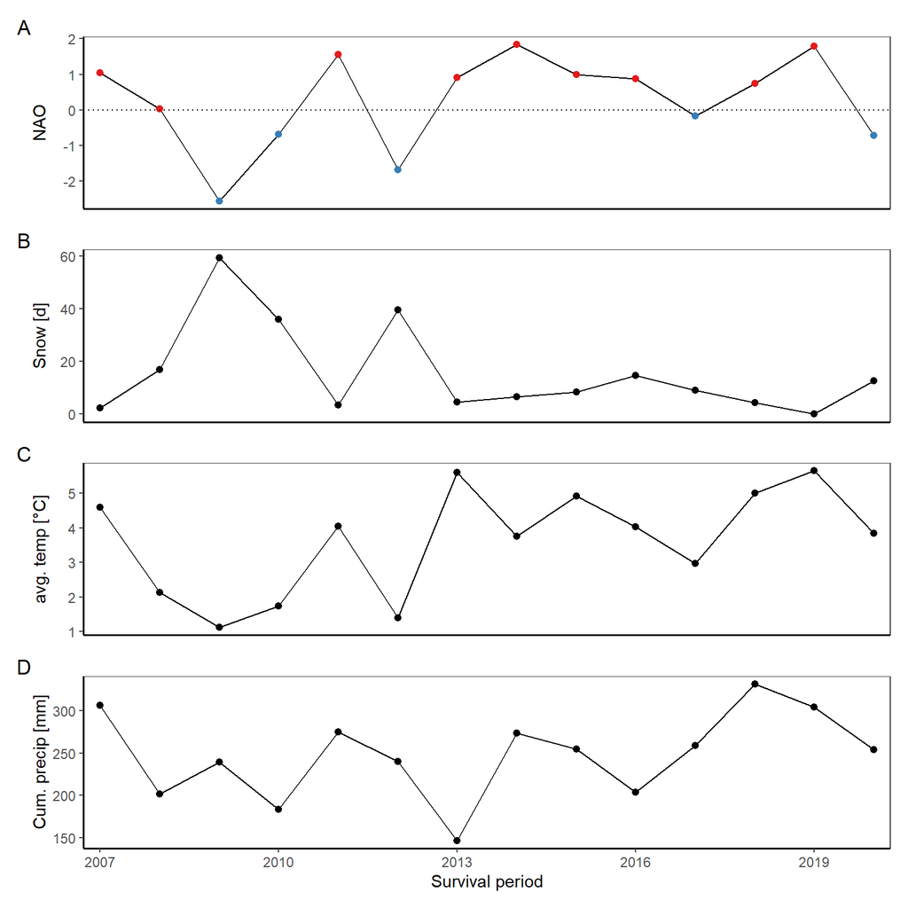

```r
nao$sign <- ifelse(nao$DJFM > 0, "+", "-")
p.nao <-
    ggplot(filter(nao, year > 2007),
           aes(x = year - 1, y = DJFM, col = sign)) +
    geom_line(col = "black") +
    geom_point(size = 1.75) +
    theme_article() +
    theme(
      legend.position = "none",
      axis.line = element_line(size = .7, color = "black"),
      panel.background = element_rect(fill = NA),
      panel.border = element_rect(fill = NA)) +
    scale_x_continuous(breaks = seq(2007, 2020, 3), expand = c(0.02,0.02)) +
    scale_color_brewer(palette = "Set1",direction = -1) +
    geom_hline(yintercept = 0, lty = "dotted") +
    xlab("Survival period") +
    ylab("NAO")

p.snow <-
    ggplot(filter(nao, year > 2007),
           aes(x = year - 1, y = snow)) +
    geom_line(col = "black") +
    geom_point(size = 1.75) +
    theme_article() +
    theme(
      legend.position = "none",
      axis.line = element_line(size = .7, color = "black"),
      panel.background = element_rect(fill = NA),
      panel.border = element_rect(fill = NA)) +
    scale_x_continuous(breaks = seq(2007, 2020, 3), expand = c(0.02,0.02)) +
    scale_color_brewer(palette = "Set1",direction = -1) +
    xlab("Survival period") +
    ylab("Snow [d]")

p.temp <-
    ggplot(filter(nao, year > 2007),
           aes(x = year - 1, y = temp)) +
    geom_line(col = "black") +
    geom_point(size = 1.75) +
    theme_article() +
    theme(
      legend.position = "none",
      axis.line = element_line(size = .7, color = "black"),
      panel.background = element_rect(fill = NA),
      panel.border = element_rect(fill = NA)) +
    scale_x_continuous(breaks = seq(2007, 2020, 3), expand = c(0.02,0.02)) +
    scale_color_brewer(palette = "Set1",direction = -1) +
    xlab("Survival period") +
    ylab("avg. temp [°C]")

p.precip <-
    ggplot(filter(nao, year > 2007),
           aes(x = year - 1, y = precip)) +
    geom_line(col = "black") +
    geom_point(size = 1.75) +
    theme_article() +
    theme(
      legend.position = "none",
      axis.line = element_line(size = .7, color = "black"),
      panel.background = element_rect(fill = NA),
      panel.border = element_rect(fill = NA)) +
    scale_x_continuous(breaks = seq(2007, 2020, 3), expand = c(0.02,0.02)) +
    scale_color_brewer(palette = "Set1",direction = -1) +
    xlab("Survival period") +
    ylab("Cum. precip [mm]")


Fig_S4 <- p.nao +
  theme(axis.text.x = element_blank(),
        axis.title.x = element_blank(),
        axis.ticks.x = element_blank()) +
  p.snow +
  theme(axis.text.x = element_blank(),
        axis.title.x = element_blank(),
        axis.ticks.x = element_blank()) +
  p.temp +
  theme(axis.text.x = element_blank(),
        axis.title.x = element_blank(),
        axis.ticks.x = element_blank()) +
  p.precip  +
  plot_annotation(tag_levels = "A") +
  plot_layout(ncol = 1)
Fig_S4
```

```r
ggsave(plot = Fig_S4, filename = "plots/Fig_S4.pdf",
       width = 6, height = 6, units = "in", device = "pdf",
       dpi = 1200)
ggsave(plot = Fig_S4, filename = "plots/Fig_S4.png",
       width = 6, height = 6, units = "in", device = "png",
       dpi = 1200)
```

##### Relationship body condition and brood rank

Show association between brood rank and body condition

```r
## subset dataset to include all-wingtaged individuals as used above
## -----------------------------------------------------------------------------
ringing_data <- filter(
  ringing_data,
  # Subset to wing-tagged only
  Tag ==  1,
  # Remove birds that died in the nest
  !CauseDeath %in% "Dead as chick",
  # Remove two birds predated as nestling
  !Ring %in% c("3408543", "3417787"),
  # known Sex
  !is.na(Sex),
  # No missing covariate
  !is.na(Lprev),
  # Keep birds with assigned morph
  Morph %in% 2:4) %>%
  #mutate(Rank = case_when(Rank == "1" ~ "A", Rank != "1" ~ "B")) %>%
  mutate(Lbinom = as.factor(ifelse(Lprev == 0, "Uninfected", "Infected"))) %>%
  ## scale continuous variables
  mutate(Hatch = scale(Hatch)) %>%
  mutate(Age_days = scale(Age_days)) %>%
  mutate(BCI = scale(BCI))

## Code Brood Rank as a factor with four levels
## -----------------------------------------------------------------------------
ringing_data$Rank[ringing_data$Rank %in% c("4", "5")] <- "4/5"

## LMER testing for differences in average condition based on brood rank
## -----------------------------------------------------------------------------
mod <- lmer(BCI ~ Rank + Brood_Size + (1|Brood_ID) + (1|Year), data =  ringing_data)
tab_model(mod, show.stat = T, show.se = T, show.ci = F, string.est = 'est', string.se = 'se', string.stat = 't')
```

|  | BCI |  |  |  |
| --- | --- | --- | --- | --- |
| Predictors | est | se | t | p |
| (Intercept) | 0.11 | 0.09 | 1.20 | 0.229 |
| Rank [2] | -0.25 | 0.03 | -7.90 | **<0.001** |
| Rank [3] | -0.38 | 0.04 | -8.70 | **<0.001** |
| Rank [4/5] | -0.90 | 0.11 | -7.87 | **<0.001** |
| Brood Size | -0.00 | 0.03 | -0.05 | 0.957 |
| Random Effects |  |  |  |  |
| σ<sup>2</sup> | 0.46 |  |  |  |
| τ<sub>00</sub> <sub>Brood_ID</sub> | 0.46 |  |  |  |
| τ<sub>00</sub> <sub>Year</sub> | 0.05 |  |  |  |
| ICC | 0.52 |  |  |  |
| N <sub>Brood_ID</sub> | 1377 |  |  |  |
| N <sub>Year</sub> | 13 |  |  |  |
| Observations | 2723 |  |  |  |
| Marginal R<sup>2</sup> / Conditional R<sup>2</sup> | 0.032 / 0.539 |  |  |  |

```r
## Check model performance and assumptions
## -----------------------------------------------------------------------------
#performance::check_model(mod)
#performance::check_distribution(mod)
#performance::model_performance(mod)

## Predicted values for each treatment
## -----------------------------------------------------------------------------
(pred <- get_model_data(mod, type = 'pred', terms = "Rank"))
```

```
#> # Predicted values of BCI
#>
#> Rank | Predicted |       95% CI | group_col
#> -------------------------------------------
#>    1 |      0.11 | -0.03,  0.24 |         1
#>    2 |     -0.14 | -0.28,  0.00 |         1
#>    3 |     -0.27 | -0.42, -0.13 |         1
#>    4 |     -0.79 | -1.04, -0.54 |         1
#>
#> Adjusted for:
#> * Brood_Size = 2.50
#> *   Brood_ID = 0 (population-level)
#> *       Year = 0 (population-level)
```

```r
pred$Rank <- c("1","2","3", "4/5")

## Calculate tukey-contrasts based on the above model
## -----------------------------------------------------------------------------
(contrasts <-
emmeans::contrast(emmeans::emmeans(mod, "Rank"), 'tukey') %>%
  broom::tidy())
```

```
#> # A tibble: 6 × 8
#>   term  contrast  null.value estimate std.error    df statistic  adj.p.value
#>   <chr> <chr>          <dbl>    <dbl>     <dbl> <dbl>     <dbl>        <dbl>
#> 1 Rank  1 - 2              0    0.247    0.0312 1513.      7.90 0
#> 2 Rank  1 - 3              0    0.383    0.0440 1468.      8.70 0
#> 3 Rank  1 - (4/5)          0    0.898    0.114  1553.      7.87 0
#> 4 Rank  2 - 3              0    0.136    0.0437 1502.      3.11 0.0103
#> 5 Rank  2 - (4/5)          0    0.651    0.114  1576.      5.73 0.0000000704
#> 6 Rank  3 - (4/5)          0    0.516    0.115  1576.      4.48 0.0000471
## create data frame to indicate significance of contrasts
## -----------------------------------------------------------------------------
```

```r
(letters.df <- data.frame(
  Rank = pred[["Rank"]],
  BCI = pred[["conf.high"]],
  label = c("a", "b", "c", "d")))
```

```
#>   Rank          BCI label
#> 1    1  0.243041397     a
#> 2    2 -0.001358349     b
#> 3    3 -0.125604409     c
#> 4  4/5 -0.536966828     d
## Plot Relationship between condition and rank
## -----------------------------------------------------------------------------
```

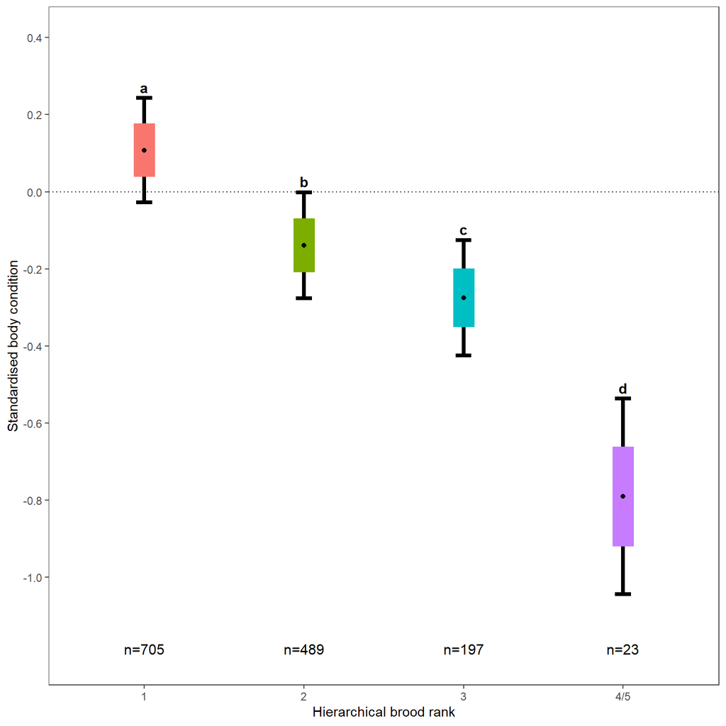

```r
Fig_S7 <- ggplot(pred, aes(x = Rank, y = predicted, fill = Rank, col = Rank)) +
  geom_errorbar(aes(ymin = conf.low, ymax = conf.high),
                colour = 'black', size = 1.5, width = .1) +
  geom_errorbar(aes(ymin = predicted - std.error,
                    ymax = predicted + std.error) ,
                size = 8, width = 0) +
  scale_y_continuous(limits = c(-1.2, 0.4), breaks = seq(-1,0.4,0.2)) +
  geom_point(col = "Black") +
  theme_article() +
  theme(legend.position = "none") +
  stat_n_text(data = ringing_data, aes(x = Rank, y = BCI),
              y.pos = -1.2, vjust = 0, y.expand.factor = 0.5) +
  xlab("Hierarchical brood rank") +
  ylab("Standardised body condition") +
  geom_hline(yintercept = 0, lty = "dotted") +
  geom_text(data = letters.df, aes(x = Rank, y = BCI, label = label),
            size = 4, color = "black", hjust = 0.5, vjust = -0.5, fontface = "bold")
  #labs(title = "Model predictions", subtitle = "GLMM: BCI ~ Rank + Brood_Size + (1|Brood_ID) + (1|Year) ")
Fig_S7
```

```r
ggsave(plot = Fig_S7, filename = "plots/Fig_S7.pdf",
       device = "pdf", dpi = 1200, width = 6, height = 6, units = "in")
ggsave(plot = Fig_S7, filename = "plots/Fig_S7.png",
       device = "png", dpi = 1200, width = 6, height = 6, units = "in")
```